# Stock Market Trend Forecast

Technical Analysis

Quantitative Analysis

Time Series

Machine Learning

Author

Hoang Son Lai

Published

April 12, 2026

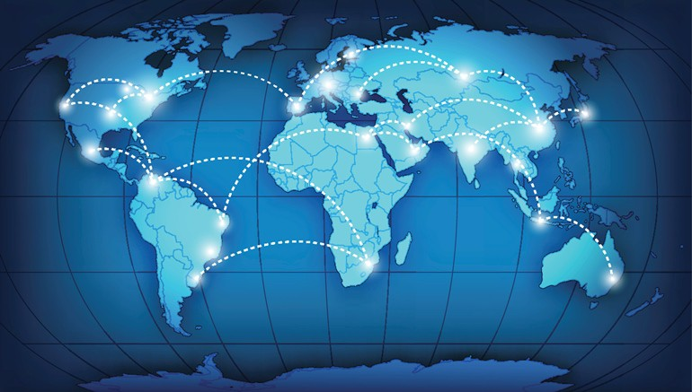

## Introduction

Navigating modern financial markets requires more than just identifying trends; it demands a rigorous, systematic approach to balancing potential alpha against inherent market risks. Traditional investment strategies often fail by relying too heavily on a single dimension, such as purely technical price action or isolated statistical models, leaving portfolios vulnerable to sudden regime shifts and volatility clustering.

This report presents a comprehensive, multi-factor quantitative trading framework designed to extract alpha over a 63-trading-day (quarterly) horizon systematically. Built upon a highly liquid universe of 21 US large-cap equities spanning from April 2019 to April 2026, the framework evaluates assets through four distinct analytical pillars:

- Technical Analysis: Quantifying short-term momentum, trend alignment, and volume conviction.
- Quantitative Analysis: Evaluating historical risk-adjusted resilience alongside forward-looking Monte Carlo simulations (Probability of Profit and 95% Value at Risk) explicitly projected over the next 63 days.
- Time Series Forecasting: Deploying an adaptive ARIMA + GARCH architecture to forecast 63-day directional drift while systematically neutralizing high-volatility environments and unforecastable assets via a strict Mean Absolute Percentage Error (MAPE) confidence filter.
- Machine Learning Classification: Utilizing Hidden Markov Models (HMM) for macroeconomic regime detection, coupled with machine learning models to probabilistically forecast extreme price movements over the targeted holding period.

By targeting a 63-day forecast window, the system intentionally filters out intraday market noise and aligns with corporate earnings cycles. The ultimate objective of this model is not to predict every market tick, but to execute high-conviction, asymmetrical bets that compound wealth efficiently while minimizing turnover and structural risk.

## Data Description

```python
import pandas as pd
import numpy as np
import seaborn as sns
import matplotlib.pyplot as plt
from pandas.plotting import table
import os
import plotly.express as px
import plotly.graph_objects as go
from plotly.subplots import make_subplots
import plotly.io as pio
pio.renderers.default = "notebook_connected"
pio.templates.default = "plotly_white"
import pandas as pd
import pandas_ta as ta
import mplfinance as mpf
import seaborn as sns
from datetime import datetime, timedelta
import warnings
import time
warnings.filterwarnings('ignore')

# To convert to html, quarto render ml_report.ipynb

# ============================================================
# PART 1: IMPORTS & SETUP
# ============================================================

# Statistical & ML Models
from statsmodels.tsa.arima.model import ARIMA
from sklearn.linear_model import LogisticRegression
from sklearn.ensemble import RandomForestClassifier
from sklearn.metrics import roc_auc_score
from xgboost import XGBClassifier
from sklearn.preprocessing import StandardScaler
from hmmlearn import hmm  # For Hidden Markov Models

# ============================================================================================================
# TIME SERIES FORECASTING IMPORTS
# ============================================================================================================

import warnings
warnings.filterwarnings('ignore')

# ARIMA and Statistical Tests
from statsmodels.tsa.arima.model import ARIMA
from statsmodels.tsa.stattools import adfuller, acf, pacf
from statsmodels.graphics.tsaplots import plot_acf, plot_pacf
from pmdarima import auto_arima

# GARCH (volatility modeling)
from arch import arch_model

# Progress tracking
from tqdm import tqdm

# Deep Learning
import tensorflow as tf
from tensorflow.keras.models import Sequential
from tensorflow.keras.layers import LSTM, Dense, Dropout, BatchNormalization
from tensorflow.keras.callbacks import EarlyStopping
from tensorflow.keras.optimizers import Adam

# Evaluation Metrics
from sklearn.metrics import (accuracy_score, precision_score, recall_score,
                            f1_score, confusion_matrix, classification_report)

# Set seeds for reproducibility
np.random.seed(42)
tf.random.set_seed(42)
```

```python
# ==============================================
# SECTION: DATA DESCRIPTION
# ==============================================

# Import necessary libraries
import pandas as pd
import numpy as np
import matplotlib.pyplot as plt
import seaborn as sns

# 1. Load Data
df = pd.read_csv('report_data/stock_prices.csv', parse_dates=['date'])

# 2. Basic Information
print("="*50)
print("DATASET OVERVIEW")
print("="*50)
print(f"Shape (Rows, Columns): {df.shape}")
print(f"Date Range: {df['date'].min().date()} to {df['date'].max().date()}")
print(f"Number of Unique Tickers: {df['ticker'].nunique()}")
print(f"Ticker List: {sorted(df['ticker'].unique().tolist())}")
print(f"\nMissing Values:\n{df.isnull().sum()}")

# 3. Sample Data
print("\n" + "="*50)
print("SAMPLE DATA (First 5 Rows)")
print("="*50)
display(df.head())

# 4. Distribution Check
ticker_counts = df['ticker'].value_counts().sort_index()

# Check if panel is balanced
if ticker_counts.nunique() == 1:
    print(f"\n✅ Dataset is balanced. Each ticker has exactly {ticker_counts.iloc[0]} trading days.")
else:
    print("\n⚠️ Dataset is unbalanced.")
```

```
==================================================
DATASET OVERVIEW
==================================================
Shape (Rows, Columns): (36939, 8)
Date Range: 2019-04-09 to 2026-04-08
Number of Unique Tickers: 21
Ticker List: ['AAPL', 'ADBE', 'AMZN', 'BAC', 'DIS', 'GOOGL', 'HD', 'JNJ', 'JPM', 'KO', 'MA', 'META', 'MSFT', 'NFLX', 'NVDA', 'PG', 'PYPL', 'TSLA', 'UNH', 'V', 'WMT']

Missing Values:
ticker       0
date         0
open         0
high         0
low          0
close        0
adj_close    0
volume       0
dtype: int64

==================================================
SAMPLE DATA (First 5 Rows)
==================================================
```

|  | ticker | date | open | high | low | close | adj_close | volume |
| --- | --- | --- | --- | --- | --- | --- | --- | --- |
| 0 | AAPL | 2019-04-09 | 47.777149 | 48.380564 | 47.517176 | 47.581573 | 47.581573 | 143072800 |
| 1 | AAPL | 2019-04-10 | 47.385992 | 47.877313 | 47.266739 | 47.848690 | 47.848690 | 86781200 |
| 2 | AAPL | 2019-04-11 | 47.903554 | 47.939328 | 47.328758 | 47.450394 | 47.450394 | 83603200 |
| 3 | AAPL | 2019-04-12 | 47.510031 | 47.734225 | 46.796906 | 47.431324 | 47.431324 | 111042800 |
| 4 | AAPL | 2019-04-15 | 47.362148 | 47.665049 | 47.226198 | 47.517174 | 47.517174 | 70146400 |

```
✅ Dataset is balanced. Each ticker has exactly 1759 trading days.
```

This dataset provides a robust historical record of market performance for 21 unique tickers, spanning from April 9, 2019, to April 8, 2026.

Notably, the data exhibits exceptional quality and balance: every ticker contains exactly 1,759 trading days, ensuring a uniform time-series structure. With 0% missing values and no duplicate entries found, this clean dataset serves as a reliable foundation for technical analysis and algorithmic backtesting.

## Part 1: Technical Analysis

### 1.1 Overview

In this section, I implement a systematic scoring framework based on classical technical indicators. The goal is to quantify the short-term momentum and structural health of a stock on a scale from -5 (Strongly Bearish) to +5 (Strongly Bullish) .

**Philosophy:** Rather than using technical indicators as standalone “Buy/Sell” signals, we decompose them into a weighted scoring rubric. This removes subjectivity and allows for backtesting and cross-sectional comparison across the 21 tickers.

**Scoring Components & Weights**

[output not shown]

### 1.2 Indicator Calculation and Scoring Implementation

```python
# ============================================================================================================
# TECHNICAL INDICATOR CALCULATION FUNCTIONS
# ============================================================================================================

def calculate_technical_indicators(df_ticker):
    """
    Calculate all required technical indicators for a single ticker.
    Assumes data is sorted chronologically.
    """
    df = df_ticker.copy()
    close = df['adj_close']
    high = df['high']
    low = df['low']
    volume = df['volume']

    # ----- Moving Averages -----
    df['sma_20'] = close.rolling(20).mean()
    df['sma_50'] = close.rolling(50).mean()
    df['sma_200'] = close.rolling(200).mean()

    # ----- Volume Moving Average -----
    df['volume_ma_20'] = volume.rolling(20).mean()
    df['volume_ratio'] = volume / (df['volume_ma_20'] + 1e-10)

    # ----- RSI (14-period) -----
    delta = close.diff()
    gain = delta.where(delta > 0, 0).rolling(14).mean()
    loss = (-delta.where(delta < 0, 0)).rolling(14).mean()
    rs = gain / (loss + 1e-10)
    df['rsi'] = 100 - (100 / (1 + rs))
    df['rsi_prev'] = df['rsi'].shift(1)

    # ----- Bollinger Bands (20, 2) -----
    df['bb_middle'] = df['sma_20']
    bb_std = close.rolling(20).std()
    df['bb_upper'] = df['bb_middle'] + 2 * bb_std
    df['bb_lower'] = df['bb_middle'] - 2 * bb_std
    df['bb_pct'] = (close - df['bb_lower']) / (df['bb_upper'] - df['bb_lower'] + 1e-10)
    df['bb_width'] = (df['bb_upper'] - df['bb_lower']) / (df['bb_middle'] + 1e-10)
    df['bb_width_prev'] = df['bb_width'].shift(5)

    # MACD Histogram
    ema12 = close.ewm(span=12, adjust=False).mean()
    ema26 = close.ewm(span=26, adjust=False).mean()
    macd_line = ema12 - ema26
    signal_line = macd_line.ewm(span=9, adjust=False).mean()
    df['macd_hist'] = macd_line - signal_line
    df['macd_hist_prev'] = df['macd_hist'].shift(1)

    return df
```

```python
# ============================================================================================================
# TECHNICAL SCORING FUNCTION
# ============================================================================================================

def calculate_technical_score(row):
    """
    Calculate technical score for a single row.
    Range: -10 to +10 (will be scaled to -5 to +5 later)
    """
    score = 0.0

    # --------------------------------------------------------------------------------------------------------
    # 1. PRICE STRUCTURE (Max ±2.0 points)
    # --------------------------------------------------------------------------------------------------------
    close = row['adj_close']
    sma20 = row['sma_20']
    sma50 = row['sma_50']

    if not pd.isna(close) and not pd.isna(sma20) and not pd.isna(sma50):
        above_both = close > sma20 and close > sma50
        below_both = close < sma20 and close < sma50
        mixed = (close > sma20 and close < sma50) or (close < sma20 and close > sma50)

        if above_both:
            score += 2.0   # Strong bullish structure
        elif below_both:
            score -= 2.0   # Strong bearish structure
        elif mixed:
            # Check which side it's leaning
            if close > sma20 and close < sma50:
                score += 0.5   # Above short-term but below medium-term (pullback within uptrend?)
            elif close < sma20 and close > sma50:
                score -= 0.5   # Below short-term but above medium-term (bounce within downtrend?)

    # --------------------------------------------------------------------------------------------------------
    # 2. TREND ALIGNMENT (Max ±2.0 points)
    # --------------------------------------------------------------------------------------------------------
    sma200 = row['sma_200']

    if not pd.isna(sma50) and not pd.isna(sma200):
        if sma50 > sma200:
            score += 2.0  # Golden Cross territory (uptrend)
        elif sma50 < sma200:
            score -= 2.0  # Death Cross territory (downtrend)

    # --------------------------------------------------------------------------------------------------------
    # 3. RSI - REGIME SWITCHING (Max ±2.0 points)
    # --------------------------------------------------------------------------------------------------------
    rsi = row['rsi']
    rsi_prev = row['rsi_prev']

    if not pd.isna(rsi) and not pd.isna(rsi_prev):
        # 🟢 TREND MODE (Preferred for momentum stocks)
        if 55 < rsi <= 70:
            score += 2.0  # Strong bullish momentum
        elif 50 < rsi <= 55:
            score += 1.0  # Building momentum

        # 🔵 MEAN REVERSION MODE (Oversold bounce potential)
        elif rsi < 30 and rsi > rsi_prev:
            score += 2.0  # Oversold and turning up -> High probability bounce

        # 🔻 BEAR MOMENTUM (Penalize heavily)
        elif rsi > 70 and rsi < rsi_prev:
            score -= 2.0  # Overbought risk

        elif 30 < rsi < 50:
            score -= 1.0

    # --------------------------------------------------------------------------------------------------------
    # 4. VOLUME CONVICTION (Max ±1.5 points)
    # --------------------------------------------------------------------------------------------------------
    volume_ratio = row['volume_ratio']
    daily_return = row.get('returns_1d', 0)

    if not pd.isna(volume_ratio) and volume_ratio > 1.2:
        if daily_return > 0:
            score += 1.5  # High volume accumulation
        elif daily_return < 0:
            score -= 1.5  # High volume distribution

    # --------------------------------------------------------------------------------------------------------
    # 5. BOLLINGER BANDS (Max ±1.5 points)
    # --------------------------------------------------------------------------------------------------------
    bb_pct = row['bb_pct']
    bb_width = row['bb_width']
    bb_width_prev = row['bb_width_prev']
    rsi_val = row['rsi']

    if not pd.isna(bb_pct) and not pd.isna(bb_width) and not pd.isna(bb_width_prev):
        # 🟢 Breakout Signal
        if bb_pct > 0.8 and bb_width > bb_width_prev:
            score += 1.0
        # 🔻 Breakdown Signal
        elif bb_pct < 0.2 and bb_width > bb_width_prev:
            score -= 1.0
        # 🔵 Mean Reversion Bounce
        elif bb_pct < 0.2 and not pd.isna(rsi_val) and rsi_val < 30 and rsi_val > row['rsi_prev']:
            score += 0.5


    # 6. MACD HISTOGRAM (Max ±1.0)
    # --------------------------------------------------------------------------------------------------------
    macd_hist = row.get('macd_hist', 0)
    macd_prev = row.get('macd_hist_prev', 0)

    if not pd.isna(macd_hist) and not pd.isna(macd_prev):
        if macd_hist > 0 and macd_hist > macd_prev:      # Bullish acceleration
            score += 1.0
        elif macd_hist < 0 and macd_hist < macd_prev:    # Bearish acceleration
            score -= 1.0

    return score
```

```python
# ============================================================================================================
# APPLY TECHNICAL SCORING TO ALL TICKERS
# ============================================================================================================

print("Calculating technical indicators and scores for all tickers...")

all_tech_scores = []

for ticker in df['ticker'].unique():
    # Filter and sort data
    ticker_data = df[df['ticker'] == ticker].copy().sort_values('date')

    # Calculate indicators
    ticker_data = calculate_technical_indicators(ticker_data)
    ticker_data['returns_1d'] = ticker_data['adj_close'].pct_change()

    # Calculate raw technical score (-10 to +10)
    ticker_data['tech_score_raw'] = ticker_data.apply(calculate_technical_score, axis=1)

    # Scale to final range [-5, +5]
    ticker_data['tech_score'] = ticker_data['tech_score_raw'] / 2.0

    # Ensure bounds (clamp to [-5, 5] just in case)
    ticker_data['tech_score'] = ticker_data['tech_score'].clip(-5, 5)

    ticker_data['ticker'] = ticker
    all_tech_scores.append(ticker_data[['ticker', 'date', 'adj_close', 'volume',
                                        'sma_20', 'sma_50', 'sma_200', 'rsi', 'macd_hist', 'macd_hist_prev',
                                        'bb_pct', 'volume_ratio', 'tech_score_raw', 'tech_score',
                                        'rsi_prev', 'bb_width', 'bb_width_prev', 'returns_1d']])

tech_df = pd.concat(all_tech_scores, ignore_index=True)
tech_df = tech_df.dropna(subset=['tech_score'])

print(f"\n✅ Technical scoring complete!")
print(f"   Final dataset: {len(tech_df):,} rows with valid scores")
```

```
Calculating technical indicators and scores for all tickers...

✅ Technical scoring complete!
   Final dataset: 36,939 rows with valid scores
```

### 1.3 Current Technical Scores (Latest Date)

```python
import pandas as pd
import numpy as np
from IPython.display import HTML, display

# ============================================================================================================
# FORMATTING & STYLING LOGIC
# ============================================================================================================

def format_tech_score_table(latest_scores):
    df = latest_scores.copy()

    # 1. Format numerical values for display
    df['Price'] = df['adj_close'].apply(lambda x: f"${x:>8,.2f}")
    df['SMA20'] = df['sma_20'].apply(lambda x: f"${x:>8,.2f}" if pd.notna(x) else "N/A")
    df['SMA50'] = df['sma_50'].apply(lambda x: f"${x:>8,.2f}" if pd.notna(x) else "N/A")
    df['SMA200'] = df['sma_200'].apply(lambda x: f"${x:>8,.2f}" if pd.notna(x) else "N/A")

    df['RSI'] = df['rsi'].apply(lambda x: f"{x:>5.1f}" if pd.notna(x) else "N/A")
    df['BB_%B'] = df['bb_pct'].apply(lambda x: f"{x:>5.2f}" if pd.notna(x) else "N/A")
    df['Vol_Ratio'] = df['volume_ratio'].apply(lambda x: f"{x:>5.2f}x" if pd.notna(x) else "N/A")
    df['MACD_Hist'] = df['macd_hist'].apply(lambda x: f"{x:>+6.2f}" if pd.notna(x) else "N/A")

    df['Tech_Score'] = df['tech_score'].apply(lambda x: f"{x:>+6.2f}")

    # 2. Select columns to show
    df_display = df[['ticker', 'Price', 'SMA20', 'SMA50', 'SMA200', 'RSI', 'BB_%B', 'Vol_Ratio', 'MACD_Hist', 'Tech_Score']]
    df_display.columns = ['Ticker', 'Price', 'SMA20', 'SMA50', 'SMA200', 'RSI', 'BB %B', 'Vol', 'MACD Hist', 'Tech Score']

    styled = df_display.style

    # 3. Define styling functions mapping strictly to the scoring logic

    # --- PRICE STRUCTURE ---
    def style_sma20(col):
        colors = []
        for p, s in zip(df['adj_close'], df['sma_20']):
            if pd.isna(p) or pd.isna(s): colors.append('')
            elif p > s: colors.append('color: #28a745; font-weight: bold;') # Price > SMA20
            else: colors.append('color: #dc3545; font-weight: bold;')       # Price < SMA20
        return colors

    def style_sma50(col):
        colors = []
        for p, s in zip(df['adj_close'], df['sma_50']):
            if pd.isna(p) or pd.isna(s): colors.append('')
            elif p > s: colors.append('color: #28a745; font-weight: bold;') # Price > SMA50
            else: colors.append('color: #dc3545; font-weight: bold;')       # Price < SMA50
        return colors

    # --- TREND ALIGNMENT ---
    def style_sma200(col):
        colors = []
        for s50, s200 in zip(df['sma_50'], df['sma_200']):
            if pd.isna(s50) or pd.isna(s200): colors.append('')
            elif s50 > s200: colors.append('color: #28a745; font-weight: bold;') # Golden Cross (+2.0)
            else: colors.append('color: #dc3545; font-weight: bold;')            # Death Cross (-2.0)
        return colors

    # --- MACD HISTOGRAM ---
    def style_macd(col):
        colors = []
        macd_prev = df.get('macd_hist_prev', df['macd_hist'])
        for m, prev in zip(df['macd_hist'], macd_prev):
            if pd.isna(m) or pd.isna(prev): colors.append('')
            elif m > 0 and m > prev: colors.append('color: #28a745; font-weight: bold;') # Bullish Accel (+1.0)
            elif m < 0 and m < prev: colors.append('color: #dc3545; font-weight: bold;') # Bearish Accel (-1.0)
            else: colors.append('color: #6c757d;')
        return colors

    # --- RSI ---
    def style_rsi(col):
        colors = []
        rsi_prev = df.get('rsi_prev', df['rsi'])
        for val, prev in zip(df['rsi'], rsi_prev):
            if pd.isna(val): colors.append('')
            elif val > 70:
                if pd.notna(prev) and val < prev:
                    colors.append('background-color: rgba(220, 53, 69, 0.4)') # Overbought Risk (-2.0)
                else:
                    colors.append('background-color: rgba(40, 167, 69, 0.3)') # Riding trend (0.0)
            elif 55 < val <= 70:
                colors.append('background-color: rgba(40, 167, 69, 0.4)')     # Strong Bullish (+2.0)
            elif 50 < val <= 55:
                colors.append('background-color: rgba(40, 167, 69, 0.2)')     # Building Momentum (+1.0)
            elif 30 < val < 50:
                colors.append('background-color: rgba(220, 53, 69, 0.2)')     # Bearish Zone (-1.0)
            else: # < 30
                if pd.notna(prev) and val > prev:
                    colors.append('background-color: rgba(40, 167, 69, 0.4)') # Mean Reversion Bounce (+2.0)
                else:
                    colors.append('background-color: rgba(220, 53, 69, 0.3)') # Oversold / Crashing (0.0)
        return colors

    # --- VOLUME CONVICTION ---
    def style_vol(col):
        colors = []
        returns = df.get('returns_1d', pd.Series([0]*len(df)))
        for val, ret in zip(df['volume_ratio'], returns):
            if pd.isna(val): colors.append('')
            elif val > 1.2:
                intensity = min((val - 1.2) / 1.0, 1.0)
                if ret > 0:
                    colors.append(f'background-color: rgba(40, 167, 69, {0.2 + intensity * 0.3})') # Accumulation (+1.5)
                elif ret < 0:
                    colors.append(f'background-color: rgba(220, 53, 69, {0.2 + intensity * 0.3})') # Distribution (-1.5)
                else:
                    colors.append('background-color: rgba(200, 200, 200, 0.2)')
            elif val < 0.8:
                colors.append('background-color: rgba(200, 200, 200, 0.1)')
            else:
                colors.append('')
        return colors

    # --- BOLLINGER BANDS ---
    def style_bb(col):
        colors = []
        width = df.get('bb_width', pd.Series([0]*len(df)))
        w_prev = df.get('bb_width_prev', pd.Series([0]*len(df)))
        rsi_val = df.get('rsi', pd.Series([50]*len(df)))
        rsi_p = df.get('rsi_prev', pd.Series([50]*len(df)))

        for pct, w, wp, r, rp in zip(df['bb_pct'], width, w_prev, rsi_val, rsi_p):
            if pd.isna(pct): colors.append('')
            elif pct > 0.8 and w > wp:
                colors.append('background-color: rgba(40, 167, 69, 0.3)') # Breakout (+1.0)
            elif pct < 0.2 and w > wp:
                colors.append('background-color: rgba(220, 53, 69, 0.4)') # Breakdown (-1.0)
            elif pct < 0.2 and r < 30 and r > rp:
                colors.append('background-color: rgba(40, 167, 69, 0.2)') # BB Bounce (+0.5)
            else:
                colors.append('background-color: rgba(200, 200, 200, 0.1)')
        return colors
```

```python
    # --- FINAL TECH SCORE ---
    def style_tech_score(col):
        colors = []
        for val in df['tech_score']:
            if pd.isna(val): colors.append('')
            elif val < 0:
                intensity = min(abs(val) / 5, 1.0)
                colors.append(f'background-color: rgba(220, 53, 69, {0.15 + intensity * 0.5})')
            elif val > 0:
                intensity = min(val / 5, 1.0)
                colors.append(f'background-color: rgba(40, 167, 69, {0.15 + intensity * 0.5})')
            else:
                colors.append('background-color: rgba(255,255,255,1)')
        return colors

    # Apply mapping
    styled = styled.apply(style_sma20, subset=['SMA20'])
    styled = styled.apply(style_sma50, subset=['SMA50'])
    styled = styled.apply(style_sma200, subset=['SMA200'])
    styled = styled.apply(style_macd, subset=['MACD Hist'])
    styled = styled.apply(style_rsi, subset=['RSI'])
    styled = styled.apply(style_bb, subset=['BB %B'])
    styled = styled.apply(style_vol, subset=['Vol'])
    styled = styled.apply(style_tech_score, subset=['Tech Score'])

    # Global CSS
    styled = styled.set_properties(**{
        'text-align': 'center',
        'font-family': 'monospace',
        'white-space': 'nowrap'
    })

    styled = styled.set_table_styles([
        {'selector': 'th', 'props': [
            ('background-color', '#114b84'),
            ('color', '#f9fafb'),
            ('font-weight', '600'),
            ('padding', '10px 12px'),
            ('border-bottom', '2px solid #0d3b66'),
            ('text-align', 'center')
        ]},
        {'selector': 'td', 'props': [
            ('padding', '8px 12px'),
            ('border-bottom', '1px solid #e5e7eb')
        ]},
        {'selector': 'tr:hover', 'props': [('background-color', '#f8f9fa')]}
    ])

    return styled

# ============================================================================================================
# UPDATED HTML LEGEND (Strictly matching scoring function)
# ============================================================================================================

legend_html = """
<div style="font-family: monospace; font-size: 13px; padding: 15px; background-color: #f8f9fa; border-radius: 8px; margin-top: 15px; border: 1px solid #e5e7eb;">
    <table style="border-collapse: collapse; width: 100%;">
        <tr><th style="text-align:left; padding:10px; background:#114b84; color:white; border-radius: 4px 4px 0 0;" colspan="3">📖 SCORING LEGEND – Technical Score Components</th></tr>

        <tr style="border-bottom: 1px solid #e5e7eb;"><td style="padding:10px; width:20%;"><b>Price Structure<br>(SMA20 & SMA50)</b></td>
            <td style="line-height: 1.6; width:40%;">
                <span style="color:#28a745; font-weight:bold;">🟢 Both Cells Green:</span> Price > 20 & 50 (+2.0)<br>
                <span style="color:#28a745; font-weight:bold;">🟢 SMA20 Green, SMA50 Red:</span> Price > MA20 but < MA50 (+0.5)
            </td>
            <td style="line-height: 1.6; width:40%;">
                <span style="color:#dc3545; font-weight:bold;">🔴 Both Cells Red:</span> Price < 20 & 50 (-2.0)<br>
                <span style="color:#dc3545; font-weight:bold;">🔴 SMA20 Red, SMA50 Green:</span> Price < MA20 but > MA50 (-0.5)
            </td>
        </tr>

        <tr style="border-bottom: 1px solid #e5e7eb;"><td style="padding:10px;"><b>Trend Alignment<br>(SMA200)</b></td>
            <td style="color:#28a745; font-weight:bold;">🟢 Green Text: SMA50 > SMA200 (+2.0)</td>
            <td style="color:#dc3545; font-weight:bold;">🔴 Red Text: SMA50 < SMA200 (-2.0)</td>
        </tr>

        <tr style="border-bottom: 1px solid #e5e7eb;"><td style="padding:10px;"><b>RSI Momentum</b></td>
            <td style="background:rgba(40,167,69,0.2); line-height: 1.6;">
                <b>Dark Green:</b> 55 to 70 (+2.0)<br>
                <b>Dark Green:</b> &lt;30 & Rising (+2.0 Bounce)<br>
                <b>Light Green:</b> 50 to 55 (+1.0)
            </td>
            <td style="background:rgba(220,53,69,0.2); line-height: 1.6;">
                <b>Dark Red:</b> &gt;70 & Falling (-2.0 Risk)<br>
                <b>Light Red:</b> 30 to 50 (-1.0)
            </td>
        </tr>

        <tr style="border-bottom: 1px solid #e5e7eb;"><td style="padding:10px;"><b>Bollinger Bands</b></td>
            <td style="background:rgba(40,167,69,0.2); line-height: 1.6;">
                <b>Dark Green:</b> %B &gt; 0.8 & expanding (+1.0 Breakout)<br>
                <b>Light Green:</b> %B &lt; 0.2 & RSI &lt; 30 Rising (+0.5 Bounce)
            </td>
            <td style="background:rgba(220,53,69,0.2); line-height: 1.6;">
                <b>Dark Red:</b> %B &lt; 0.2 & expanding (-1.0 Breakdown)
            </td>
        </tr>

        <tr style="border-bottom: 1px solid #e5e7eb;"><td style="padding:10px;"><b>Volume Conviction</b></td>
            <td style="background:rgba(40,167,69,0.2)"><b>Green:</b> Vol Ratio &gt; 1.2x & Price Up (+1.5 Accumulation)</td>
            <td style="background:rgba(220,53,69,0.2)"><b>Red:</b> Vol Ratio &gt; 1.2x & Price Down (-1.5 Distribution)</td>
        </tr>

        <tr style="border-bottom: 1px solid #e5e7eb;"><td style="padding:10px;"><b>MACD Hist</b></td>
            <td style="color:#28a745; font-weight:bold;">🟢 Green Text: > 0 & Rising (+1.0)</td>
            <td style="color:#dc3545; font-weight:bold;">🔴 Red Text: < 0 & Falling (-1.0)</td>
        </tr>

        <tr><td style="padding:10px;"><b>Final Tech Score</b></td>
            <td style="background:rgba(40,167,69,0.3); font-weight:bold;" colspan="2">
                Raw score (-10 to +10) is scaled by half, resulting in a final range of -5.0 to +5.0.
            </td>
        </tr>
    </table>
</div>
"""

# ============================================================================================================
# EXECUTION / DISPLAY
# ============================================================================================================
```

```python
latest_date = tech_df['date'].max()
latest_scores = tech_df[tech_df['date'] == latest_date].copy()
latest_scores = latest_scores.sort_values('tech_score', ascending=False).reset_index(drop=True)

print(f"\n📅 Latest Date: {latest_date.strftime('%Y-%m-%d')}")
display(format_tech_score_table(latest_scores))
display(HTML(legend_html))
```

```
📅 Latest Date: 2026-04-08
```

|  | Ticker | Price | SMA20 | SMA50 | SMA200 | RSI | BB %B | Vol | MACD Hist | Tech Score |
| --- | --- | --- | --- | --- | --- | --- | --- | --- | --- | --- |
| 0 | GOOGL | $ 317.32 | $ 298.13 | $ 308.92 | $ 266.73 | 55.7 | 0.90 | 1.13x | +3.04 | +4.00 |
| 1 | WMT | $ 127.26 | $ 123.62 | $ 124.76 | $ 109.34 | 63.0 | 0.91 | 1.01x | +0.39 | +4.00 |
| 2 | KO | $ 77.29 | $ 76.21 | $ 77.00 | $ 70.55 | 57.5 | 0.77 | 0.82x | +0.14 | +3.50 |
| 3 | JNJ | $ 241.30 | $ 240.16 | $ 239.64 | $ 198.02 | 59.0 | 0.60 | 1.17x | -0.15 | +3.00 |
| 4 | BAC | $ 51.88 | $ 48.21 | $ 50.49 | $ 50.46 | 79.3 | 1.15 | 0.91x | +0.60 | +3.00 |
| 5 | AAPL | $ 258.90 | $ 253.06 | $ 260.71 | $ 249.70 | 62.4 | 0.88 | 1.00x | +1.20 | +2.75 |
| 6 | NVDA | $ 182.08 | $ 177.25 | $ 182.22 | $ 180.32 | 51.9 | 0.73 | 0.86x | +0.99 | +2.25 |
| 7 | AMZN | $ 221.25 | $ 209.71 | $ 213.72 | $ 224.60 | 60.8 | 1.11 | 1.21x | +1.61 | +2.25 |
| 8 | UNH | $ 305.98 | $ 278.80 | $ 281.26 | $ 308.51 | 63.3 | 1.05 | 1.01x | +4.42 | +2.00 |
| 9 | NFLX | $ 99.39 | $ 94.81 | $ 89.00 | $ 106.78 | 63.1 | 0.95 | 0.84x | +0.34 | +2.00 |
| 10 | PYPL | $ 45.85 | $ 44.93 | $ 44.98 | $ 61.13 | 55.9 | 0.85 | 0.93x | +0.19 | +1.50 |
| 11 | JPM | $ 307.97 | $ 289.26 | $ 297.59 | $ 299.80 | 71.2 | 1.21 | 0.98x | +2.56 | +1.00 |
| 12 | V | $ 308.96 | $ 303.58 | $ 314.36 | $ 334.86 | 62.3 | 0.83 | 0.94x | +1.17 | +0.75 |
| 13 | MA | $ 507.12 | $ 498.15 | $ 515.72 | $ 551.37 | 61.5 | 0.85 | 1.13x | +2.00 | +0.75 |
| 14 | HD | $ 336.16 | $ 331.00 | $ 357.22 | $ 369.01 | 53.3 | 0.66 | 1.10x | +1.45 | +0.25 |
| 15 | PG | $ 144.90 | $ 145.77 | $ 153.09 | $ 150.42 | 44.0 | 0.44 | 0.96x | +0.12 | +0.00 |
| 16 | META | $ 612.42 | $ 592.95 | $ 634.90 | $ 682.42 | 49.2 | 0.65 | 1.78x | +3.65 | +0.00 |
| 17 | DIS | $ 99.18 | $ 97.46 | $ 102.50 | $ 110.73 | 49.3 | 0.69 | 0.99x | +0.48 | -0.75 |
| 18 | MSFT | $ 374.33 | $ 380.27 | $ 397.94 | $ 473.72 | 35.1 | 0.40 | 1.05x | +1.18 | -2.00 |
| 19 | ADBE | $ 239.31 | $ 246.54 | $ 261.22 | $ 325.69 | 41.8 | 0.32 | 0.65x | +0.73 | -2.00 |
| 20 | TSLA | $ 343.25 | $ 376.26 | $ 397.66 | $ 397.33 | 32.0 | 0.05 | 1.20x | -2.39 | -2.25 |

| 📖 SCORING LEGEND – Technical Score Components |  |  |
| --- | --- | --- |
| Price Structure (SMA20 & SMA50) | 🟢 Both Cells Green: Price > 20 & 50 (+2.0) 🟢 SMA20 Green, SMA50 Red: Price > MA20 but < MA50 (+0.5) | 🔴 Both Cells Red: Price < 20 & 50 (-2.0) 🔴 SMA20 Red, SMA50 Green: Price < MA20 but > MA50 (-0.5) |
| Trend Alignment (SMA200) | 🟢 Green Text: SMA50 > SMA200 (+2.0) | 🔴 Red Text: SMA50 < SMA200 (-2.0) |
| **RSI Momentum** | **Dark Green:** 55 to 70 (+2.0) **Dark Green:** <30 & Rising (+2.0 Bounce) **Light Green:** 50 to 55 (+1.0) | **Dark Red:** >70 & Falling (-2.0 Risk) **Light Red:** 30 to 50 (-1.0) |
| **Bollinger Bands** | **Dark Green:** %B > 0.8 & expanding (+1.0 Breakout) **Light Green:** %B < 0.2 & RSI < 30 Rising (+0.5 Bounce) | **Dark Red:** %B < 0.2 & expanding (-1.0 Breakdown) |
| **Volume Conviction** | **Green:** Vol Ratio > 1.2x & Price Up (+1.5 Accumulation) | **Red:** Vol Ratio > 1.2x & Price Down (-1.5 Distribution) |
| **MACD Hist** | 🟢 Green Text: > 0 & Rising (+1.0) | 🔴 Red Text: < 0 & Falling (-1.0) |
| **Final Tech Score** | Raw score (-10 to +10) is scaled by half, resulting in a final range of -5.0 to +5.0. |  |

The technical evaluation reveals a stark divergence in short-term price structures across the universe. At the top of the board, leaders like GOOGL (+4.00) and WMT (+4.00) exhibit pristine bullish momentum; they are trading comfortably above all key moving averages (SMA20, 50, 200) with accelerating MACD histograms and healthy RSI levels (55-63) that confirm trend strength without being overextended. Conversely, the bottom of the ranking flags severe structural breakdowns, most notably in TSLA (-2.25). TSLA is trading heavily below its SMAs, trapped in a strong bearish distribution phase with a highly negative MACD (-2.39) and a Bollinger %B of 0.05, indicating price is pinned at the extreme lower band.

Overall, the technical framework is functioning exactly as intended: seamlessly rewarding stocks with confirmed, volume-supported uptrends while aggressively penalizing those caught in bearish momentum traps.

```python
# ------------------------------------------------------------------------------------------------------------
# EXPORT FOR INTEGRATION
# ------------------------------------------------------------------------------------------------------------

tech_scores_export = latest_scores[['ticker', 'tech_score', 'rsi', 'bb_pct', 'volume_ratio']].copy()
tech_scores_export.columns = ['Ticker', 'Tech_Score', 'RSI', 'BB_Pct', 'Volume_Ratio']
tech_scores_export['Date'] = latest_date.date()
tech_scores_export = tech_scores_export[['Date', 'Ticker', 'Tech_Score', 'RSI', 'BB_Pct', 'Volume_Ratio']]
tech_scores_export = tech_scores_export.sort_values('Tech_Score', ascending=False).reset_index(drop=True)
```

## Part 2: Quantitative Analysis

### 2.1 Overview

In this section, I implement a quantitative scoring framework that evaluates stocks through the lens of risk-adjusted returns and forward-looking risk simulations. While Part 1 (Technical Analysis) focuses on price action and momentum, this section addresses the critical question: *“Is the potential return worth the risk I am taking?”*

**Philosophy:** A stock with a high Sharpe Ratio and low historical drawdowns is fundamentally more “investable” than a volatile stock with erratic returns—even if both have similar absolute returns. We augment historical metrics with **Monte Carlo simulation** to probabilistically forecast risk over the 63-day horizon.

**Scoring Components & Weights**

| Component | Max Points | Weight | Rationale |
| --- | --- | --- | --- |
| 1. Sharpe Ratio (252D) | ±1.0 | 20% | Measures risk-adjusted historical performance |
| 2. Max Drawdown (252D) | ±1.0 | 20% | Measures worst-case historical pain tolerance |
| 3. Rolling Momentum (63D) | ±1.0 | 20% | Captures medium-term trend strength |
| 4. Monte Carlo: Probability of Profit | ±1.0 | 20% | Forward-looking win probability (63D horizon) |
| 5. Monte Carlo: Value at Risk (95%) | ±1.0 | 20% | Forward-looking worst-case loss estimate (63D horizon) |
| **Total Possible** | **±5.0** | 100% | Final score is the sum of all components |

### 2.2 Code Implementation

```python
# ============================================================================================================
# QUANTITATIVE METRICS CALCULATION FUNCTIONS
# ============================================================================================================

def calculate_sharpe_ratio(returns, risk_free_rate=0.03, periods_per_year=252):
    """
    Calculate annualized Sharpe Ratio.

    Sharpe = (Annualized Return - Risk Free Rate) / Annualized Volatility

    Parameters:
    - returns: Daily returns series
    - risk_free_rate: Annual risk-free rate (default 3%)
    - periods_per_year: Trading days per year (default 252)
    """
    if len(returns) < periods_per_year:
        return np.nan

    # Use last 252 trading days
    recent_returns = returns.tail(periods_per_year)

    ann_return = recent_returns.mean() * periods_per_year
    ann_vol = recent_returns.std() * np.sqrt(periods_per_year)

    if ann_vol == 0:
        return 0.0

    sharpe = (ann_return - risk_free_rate) / ann_vol
    return sharpe


def calculate_max_drawdown(prices, window=252):
    """
    Calculate Maximum Drawdown over the specified window.
    MDD = (Trough - Peak) / Peak
    """
    if len(prices) < window:
        return np.nan

    recent_prices = prices.tail(window)
    rolling_max = recent_prices.expanding().max()
    drawdown = (recent_prices / rolling_max) - 1
    mdd = drawdown.min()

    return mdd


def calculate_rolling_momentum(prices, window=63):
    """
    Calculate rolling return over the specified window.
    """
    if len(prices) < window:
        return np.nan

    momentum = (prices.iloc[-1] / prices.iloc[-window]) - 1
    return momentum
```

```python
# ============================================================================================================
# MONTE CARLO SIMULATION FOR 63-DAY HORIZON
# ============================================================================================================

def monte_carlo_simulation(prices, horizon_days=63, n_simulations=10000, random_state=42):
    """
    Simulate future price paths using Geometric Brownian Motion (GBM).

    Returns:
    - pop: Probability of Profit (final price > current price)
    - var_95: 95% Value at Risk (5th percentile of returns)
    """
    if len(prices) < 252:
        return np.nan, np.nan

    np.random.seed(random_state)

    # Calculate daily returns for parameter estimation
    returns = prices.pct_change().dropna().tail(252)

    mu = returns.mean()          # Daily drift
    sigma = returns.std()        # Daily volatility

    current_price = prices.iloc[-1]

    # Generate simulated price paths
    # GBM: S_t = S_0 * exp( (mu - 0.5*sigma^2)*t + sigma * sqrt(t) * Z )
    dt = 1
    drift = (mu - 0.5 * sigma**2) * horizon_days
    diffusion = sigma * np.sqrt(horizon_days)

    Z = np.random.standard_normal(n_simulations)
    final_prices = current_price * np.exp(drift + diffusion * Z)

    # Calculate returns distribution
    simulated_returns = (final_prices / current_price) - 1

    # Probability of Profit
    pop = np.mean(final_prices > current_price)

    # Value at Risk (95% confidence) - 5th percentile worst case
    var_95 = np.percentile(simulated_returns, 5)

    return pop, var_95
```

```python
# ============================================================================================================
# QUANTITATIVE SCORING FUNCTION
# ============================================================================================================

def calculate_quant_score_for_ticker(ticker_data, horizon_days=63):
    """
    Calculate quantitative score for a single ticker.
    Range: -5.0 to +5.0
    """
    score = 0.0

    # Ensure data is sorted chronologically
    ticker_data = ticker_data.sort_values('date').reset_index(drop=True)

    prices = ticker_data['adj_close']
    returns = prices.pct_change().dropna()

    # --------------------------------------------------------------------------------------------------------
    # 1. SHARPE RATIO (Max ±1.0 point)
    # --------------------------------------------------------------------------------------------------------
    sharpe = calculate_sharpe_ratio(returns)

    if not np.isnan(sharpe):
        if sharpe > 1.0:
            score += 1.0   # Excellent risk-adjusted returns
        elif sharpe < 0.0:
            score -= 1.0   # Negative risk-adjusted returns

    # --------------------------------------------------------------------------------------------------------
    # 2. MAX DRAWDOWN (Max ±1.0 point)
    # --------------------------------------------------------------------------------------------------------
    mdd = calculate_max_drawdown(prices)

    if not np.isnan(mdd):
        # Note: MDD is negative (e.g., -0.20 means 20% drawdown)
        if mdd > -0.15:      # Less than 15% drawdown (e.g., -10% > -15%)
            score += 1.0      # Very resilient
        elif mdd < -0.25:    # More than 25% drawdown (e.g., -30% < -25%)
            score -= 1.0      # High historical pain

    # --------------------------------------------------------------------------------------------------------
    # 3. ROLLING MOMENTUM 63D (Max ±1.0 point)
    # --------------------------------------------------------------------------------------------------------
    momentum = calculate_rolling_momentum(prices, window=63)

    if not np.isnan(momentum):
        if momentum > 0.05:
            score += 1.0   # Strong positive momentum (>5%)
        elif momentum < -0.05:
            score -= 1.0   # Strong negative momentum (<-5%)

    # --------------------------------------------------------------------------------------------------------
    # 4 & 5. MONTE CARLO METRICS (Max ±2.0 points combined)
    # --------------------------------------------------------------------------------------------------------
    pop, var_95 = monte_carlo_simulation(prices, horizon_days=horizon_days)

    # 4. Probability of Profit (Max ±1.0 point)
    if not np.isnan(pop):
        if pop > 0.60:
            score += 1.0   # High win probability
        elif pop < 0.40:
            score -= 1.0   # Low win probability

    # 5. Value at Risk 95% (Max ±1.0 point)
    if not np.isnan(var_95):
        if var_95 > -0.15:     # Worst case loss < 15%
            score += 1.0       # Low tail risk
        elif var_95 < -0.25:   # Worst case loss > 25%
            score -= 1.0       # High tail risk

    return score, sharpe, mdd, momentum, pop, var_95
```

```python
# ============================================================================================================
# APPLY QUANTITATIVE SCORING TO ALL TICKERS
# ============================================================================================================

print("Calculating quantitative scores for all tickers...")

quant_results = []

for ticker in df['ticker'].unique():
    # Filter data for this ticker
    ticker_data = df[df['ticker'] == ticker].copy()

    # Calculate quantitative score
    quant_score, sharpe, mdd, momentum, pop, var_95 = calculate_quant_score_for_ticker(ticker_data)

    quant_results.append({
        'Ticker': ticker,
        'Quant_Score': quant_score,
        'Sharpe_Ratio': sharpe,
        'Max_Drawdown': mdd,
        'Momentum_63D': momentum,
        'Prob_Profit_63D': pop,
        'VaR_95_63D': var_95
    })


quant_df = pd.DataFrame(quant_results)
quant_df = quant_df.sort_values('Quant_Score', ascending=False).reset_index(drop=True)

print(f"\n✅ Quantitative scoring complete for {len(quant_df)} tickers!")
```

```
Calculating quantitative scores for all tickers...

✅ Quantitative scoring complete for 21 tickers!
```

### 2.3 Quantitative Score

```python
# ============================================================================================================
# QUANTITATIVE SCORES - STYLED TABLE
# ============================================================================================================

from IPython.display import HTML, display

def color_gradient_quant(val, vmin=-5, vmax=5):
    """Smooth gradient for Quantitative Score"""
    if pd.isna(val):
        return ''
    if val < 0:
        intensity = min(abs(val) / abs(vmin), 1.0)
        return f'background-color: rgba(220, 53, 69, {0.15 + intensity * 0.5})'
    elif val > 0:
        intensity = min(val / vmax, 1.0)
        return f'background-color: rgba(40, 167, 69, {0.15 + intensity * 0.5})'
    else:
        return 'background-color: rgba(255,255,255,1)'


def color_gradient_sharpe(val):
    """Sharpe Ratio coloring"""
    if pd.isna(val):
        return ''
    if val > 1.0:
        return 'background-color: rgba(40, 167, 69, 0.3); font-weight: bold'
    elif val < 0:
        return 'background-color: rgba(220, 53, 69, 0.3)'
    else:
        return ''


def color_gradient_mdd(val):
    """Max Drawdown coloring (note: negative values)"""
    if pd.isna(val):
        return ''
    if val > -0.15:
        return 'background-color: rgba(40, 167, 69, 0.25)'
    elif val < -0.25:
        return 'background-color: rgba(220, 53, 69, 0.35); font-weight: bold'
    else:
        return ''


def color_gradient_momentum(val):
    """63D Momentum coloring"""
    if pd.isna(val):
        return ''
    if val > 0.05:
        return 'background-color: rgba(40, 167, 69, 0.25)'
    elif val < -0.05:
        return 'background-color: rgba(220, 53, 69, 0.25)'
    else:
        return ''


def color_gradient_pop(val):
    """Probability of Profit coloring"""
    if pd.isna(val):
        return ''
    if val > 0.60:
        return 'background-color: rgba(40, 167, 69, 0.25)'
    elif val < 0.40:
        return 'background-color: rgba(220, 53, 69, 0.25)'
    else:
        return ''


def color_gradient_var(val):
    """VaR 95% coloring (note: negative values)"""
    if pd.isna(val):
        return ''
    if val > -0.08:
        return 'background-color: rgba(40, 167, 69, 0.25)'
    elif val < -0.15:
        return 'background-color: rgba(220, 53, 69, 0.35); font-weight: bold'
    else:
        return ''


def format_quant_score_table(df):
    """Format and style the quantitative score table"""
    df_display = df.copy()

    # Format values
    df_display['Sharpe_Ratio'] = df_display['Sharpe_Ratio'].apply(lambda x: f"{x:>+7.3f}" if pd.notna(x) else "    N/A")
    df_display['Max_Drawdown'] = df_display['Max_Drawdown'].apply(lambda x: f"{x:>+7.2%}" if pd.notna(x) else "    N/A")
    df_display['Momentum_63D'] = df_display['Momentum_63D'].apply(lambda x: f"{x:>+7.2%}" if pd.notna(x) else "    N/A")
    df_display['Prob_Profit_63D'] = df_display['Prob_Profit_63D'].apply(lambda x: f"{x:>7.1%}" if pd.notna(x) else "    N/A")
    df_display['VaR_95_63D'] = df_display['VaR_95_63D'].apply(lambda x: f"{x:>+7.2%}" if pd.notna(x) else "    N/A")
    df_display['Quant_Score'] = df_display['Quant_Score'].apply(lambda x: f"{x:>+6.2f}" if pd.notna(x) else "   N/A")

    # Rename columns for display
    df_display.columns = ['Ticker', 'Quant Score', 'Sharpe', 'Max DD', 'Mom 63D', 'PoP 63D', 'VaR 95%']
    df_display = df_display[['Ticker', 'Quant Score', 'Sharpe', 'Max DD', 'Mom 63D', 'PoP 63D', 'VaR 95%']]

    # Store raw values for gradients
    raw_scores = df['Quant_Score'].values
    raw_sharpe = df['Sharpe_Ratio'].values
    raw_mdd = df['Max_Drawdown'].values
    raw_mom = df['Momentum_63D'].values
    raw_pop = df['Prob_Profit_63D'].values
    raw_var = df['VaR_95_63D'].values

    styled = df_display.style

    # Apply gradients
    def apply_styles(col):
        if col.name == 'Quant Score':
            return [color_gradient_quant(v) for v in raw_scores]
        elif col.name == 'Sharpe':
            return [color_gradient_sharpe(v) for v in raw_sharpe]
        elif col.name == 'Max DD':
            return [color_gradient_mdd(v) for v in raw_mdd]
        elif col.name == 'Mom 63D':
            return [color_gradient_momentum(v) for v in raw_mom]
        elif col.name == 'PoP 63D':
            return [color_gradient_pop(v) for v in raw_pop]
        elif col.name == 'VaR 95%':
            return [color_gradient_var(v) for v in raw_var]
        return [''] * len(col)

    styled = styled.apply(apply_styles)

    # Global styling
    styled = styled.set_properties(**{
        'text-align': 'center',
        'font-family': 'monospace',
        'white-space': 'nowrap'
    })

    styled = styled.set_table_styles([
        {'selector': 'th',
         'props': [
             ('background-color', '#1b5e20'),
             ('color', '#f9fafb'),
             ('font-weight', '600'),
             ('text-align', 'center'),
             ('padding', '10px 12px'),
             ('border-bottom', '2px solid #0d3b66')
         ]},
        {'selector': 'td',
         'props': [
             ('padding', '8px 12px'),
             ('border-bottom', '1px solid #e5e7eb')
         ]},
        {'selector': 'tr:hover',
         'props': [('background-color', '#f8f9fa')]},
        {'selector': 'table',
         'props': [
             ('border-collapse', 'collapse'),
             ('margin', '0 auto'),
             ('font-size', '13px'),
             ('box-shadow', '0 2px 8px rgba(0,0,0,0.1)')
         ]}
    ])

    return styled


print("\n" + "="*100)
print("📊 QUANTITATIVE SCORES - ALL TICKERS (Based on 252D Historical Data)")
print("="*100)

display(format_quant_score_table(quant_df))
```

```
====================================================================================================
📊 QUANTITATIVE SCORES - ALL TICKERS (Based on 252D Historical Data)
====================================================================================================
```

|  | Ticker | Quant Score | Sharpe | Max DD | Mom 63D | PoP 63D | VaR 95% |
| --- | --- | --- | --- | --- | --- | --- | --- |
| 0 | JNJ | +5.00 | +2.777 | -7.22% | +16.91% | 92.4% | -1.82% |
| 1 | WMT | +5.00 | +1.800 | -10.92% | +13.13% | 81.6% | -8.65% |
| 2 | KO | +4.00 | +0.696 | -9.82% | +15.22% | 65.6% | -9.54% |
| 3 | GOOGL | +3.00 | +2.626 | -20.37% | -1.38% | 89.9% | -5.46% |
| 4 | AAPL | +3.00 | +1.137 | -13.80% | -0.46% | 70.6% | -15.06% |
| 5 | NVDA | +2.00 | +1.769 | -20.21% | -3.71% | 79.3% | -15.31% |
| 6 | BAC | +2.00 | +1.849 | -17.93% | -6.23% | 82.3% | -8.09% |
| 7 | JPM | +2.00 | +1.713 | -15.47% | -5.33% | 80.6% | -8.79% |
| 8 | AMZN | +0.00 | +0.842 | -21.74% | -8.41% | 64.7% | -19.30% |
| 9 | DIS | +0.00 | +0.667 | -24.97% | -12.16% | 62.2% | -17.83% |
| 10 | NFLX | +0.00 | +0.522 | -43.35% | +9.54% | 58.7% | -21.36% |
| 11 | PG | -1.00 | -0.594 | -17.62% | +5.71% | 39.6% | -16.05% |
| 12 | HD | -1.00 | -0.119 | -23.72% | -3.05% | 47.7% | -18.42% |
| 13 | MA | -1.00 | +0.160 | -18.92% | -12.42% | 53.6% | -16.42% |
| 14 | MSFT | -2.00 | +0.195 | -33.91% | -22.40% | 53.6% | -18.44% |
| 15 | META | -2.00 | +0.618 | -33.30% | -5.51% | 59.9% | -24.00% |
| 16 | V | -2.00 | -0.049 | -20.38% | -13.01% | 49.4% | -17.08% |
| 17 | TSLA | -2.00 | +0.875 | -29.93% | -20.44% | 62.9% | -30.18% |
| 18 | UNH | -5.00 | -0.770 | -60.06% | -9.76% | 31.1% | -42.58% |
| 19 | PYPL | -5.00 | -0.452 | -49.92% | -21.40% | 38.6% | -32.40% |
| 20 | ADBE | -5.00 | -1.192 | -44.18% | -29.22% | 26.6% | -29.18% |

```python
# LEGEND

print("LEGEND - QUANTITATIVE METRICS")

legend_html = """
<div style="font-family: monospace; font-size: 12px; padding: 15px; background-color: #f8f9fa; border-radius: 8px;">
    <table style="border-collapse: collapse; width: 100%;">
        <tr style="background-color: #e9ecef;">
            <th style="padding: 8px; text-align: left; width: 20%;">Metric</th>
            <th style="padding: 8px; text-align: left; width: 40%;">Green (Positive)</th>
            <th style="padding: 8px; text-align: left; width: 40%;">Red (Negative)</th>
        </tr>
        <tr>
            <td style="padding: 8px;"><b>Sharpe Ratio</b></td>
            <td style="padding: 8px; background-color: rgba(40, 167, 69, 0.2);">> 1.0 → Excellent risk-adjusted return</td>
            <td style="padding: 8px; background-color: rgba(220, 53, 69, 0.2);">< 0.0 → Negative risk-adjusted return</td>
        </tr>
        <tr>
            <td style="padding: 8px;"><b>Max Drawdown</b></td>
            <td style="padding: 8px; background-color: rgba(40, 167, 69, 0.2);">> -15% → Resilient (low pain)</td>
            <td style="padding: 8px; background-color: rgba(220, 53, 69, 0.2);">< -25% → High historical pain</td>
        </tr>
        <tr>
            <td style="padding: 8px;"><b>Momentum 63D</b></td>
            <td style="padding: 8px; background-color: rgba(40, 167, 69, 0.2);">> +5% → Strong uptrend (1 quarter)</td>
            <td style="padding: 8px; background-color: rgba(220, 53, 69, 0.2);">< -5% → Strong downtrend</td>
        </tr>
        <tr>
            <td style="padding: 8px;"><b>PoP 63D</b></td>
            <td style="padding: 8px; background-color: rgba(40, 167, 69, 0.2);">> 60% → High win probability</td>
            <td style="padding: 8px; background-color: rgba(220, 53, 69, 0.2);">< 40% → Low win probability</td>
        </tr>
        <tr>
            <td style="padding: 8px;"><b>VaR 95% (63D)</b></td>
            <td style="padding: 8px; background-color: rgba(40, 167, 69, 0.2);">> -15% → Low tail risk</td>
            <td style="padding: 8px; background-color: rgba(220, 53, 69, 0.2);">< -25% → High tail risk (caution)</td>
        </tr>
        <tr>
            <td style="padding: 8px;"><b>Quant Score</b></td>
            <td style="padding: 8px; background-color: rgba(40, 167, 69, 0.3);">Positive = Favorable risk/reward</td>
            <td style="padding: 8px; background-color: rgba(220, 53, 69, 0.3);">Negative = Unfavorable risk/reward</td>
        </tr>
    </table>
</div>
"""
display(HTML(legend_html))
```

```
LEGEND - QUANTITATIVE METRICS
```

| Metric | Green (Positive) | Red (Negative) |
| --- | --- | --- |
| **Sharpe Ratio** | > 1.0 → Excellent risk-adjusted return | < 0.0 → Negative risk-adjusted return |
| **Max Drawdown** | > -15% → Resilient (low pain) | < -25% → High historical pain |
| **Momentum 63D** | > +5% → Strong uptrend (1 quarter) | < -5% → Strong downtrend |
| **PoP 63D** | > 60% → High win probability | < 40% → Low win probability |
| **VaR 95% (63D)** | > -15% → Low tail risk | < -25% → High tail risk (caution) |
| **Quant Score** | Positive = Favorable risk/reward | Negative = Unfavorable risk/reward |

**Findings**

The quantitative evaluation strictly rewards risk-adjusted resilience and capital preservation over absolute returns. Defensive stalwarts like JNJ, WMT, and KO dominate the top of the rankings with perfect or near-perfect scores (+4.00 to +5.00). Their leadership is driven by exceptional Sharpe ratios (up to 2.777 for JNJ), remarkably shallow maximum drawdowns (all better than -11%), and high forward-looking probabilities of profit.

Conversely, high-beta laggards such as ADBE, PYPL, and UNH fall to the very bottom with minimum scores of -5.00. These names are severely penalised for their highly unfavourable risk/reward profiles, characterised by negative Sharpe ratios, massive historical drawdowns exceeding -40%, and elevated tail risk (VaR 95% worse than -29%).

Ultimately, this quantitative lens functions as a ruthless risk filter, ensuring the portfolio naturally gravitates toward structurally sound, low-pain assets while avoiding erratic value traps.

**A Note on Monte Carlo Assumptions**

The Monte Carlo simulation uses **Geometric Brownian Motion (GBM)** with parameters estimated from the last 252 trading days:

- **Drift (μ):** Historical average daily return
- **Volatility (σ):** Historical standard deviation of daily returns

**Limitations to keep in mind:** 1. GBM assumes returns are normally distributed (real markets have “fat tails”). 2. The simulation uses *historical* volatility to predict *future* volatility (which can change rapidly). 3. The model does not account for upcoming earnings, macro events, or regime shifts.

Despite these limitations, the 10,000-path simulation provides a useful probabilistic framework for comparing *relative* risk across stocks.

**Why Equal Weighting Across 5 Components?**

Each of the five components captures a different dimension of risk/return:

- **Sharpe & MDD:** Backward-looking, historical performance.
- **Momentum:** Medium-term trend (quant funds love this).
- **PoP & VaR:** Forward-looking, probabilistic forecasts.

Equal weighting (20% each) ensures no single metric dominates and provides a balanced, holistic assessment.

```python
# ============================================================================================================
# EXPORT QUANTITATIVE SCORES FOR INTEGRATION
# ============================================================================================================

quant_scores_export = quant_df[['Ticker', 'Quant_Score', 'Sharpe_Ratio', 'Max_Drawdown',
                                 'Momentum_63D', 'Prob_Profit_63D', 'VaR_95_63D']].copy()
quant_scores_export.columns = ['Ticker', 'Quant_Score', 'Sharpe_Ratio', 'Max_Drawdown',
                               'Momentum_63D', 'Prob_Profit_63D', 'VaR_95_63D']
```

## Part 3: Time Series Forecasting - ARIMA + GARCH

### 3.1 Overview

In this section, I implement a hybrid time series forecasting framework that combines:

1. ARIMA (AutoRegressive Integrated Moving Average): Captures the conditional mean of the series - i.e., the expected price direction and magnitude.
2. GARCH (Generalized AutoRegressive Conditional Heteroskedasticity): Captures the conditional volatility - i.e., the expected risk and uncertainty around the forecast.

**Why combine both?**

ARIMA alone assumes constant volatility (homoskedasticity), which is unrealistic for financial data. Stock returns exhibit volatility clustering (periods of high volatility tend to be followed by more high volatility). GARCH explicitly models this phenomenon, allowing us to:

- Adjust forecast confidence intervals based on current market turbulence.
- Penalize forecasts made during high-volatility regimes (wider confidence bands = less conviction).

**Scoring Components & Weights**

[output not shown]

### 3.2 Time Series Model Evaluation & Diagnostics

Before forecasting the unknown future, we must test the models on the known past. Instead of a slow walk-forward backtest, I use a Chronological Train/Test Split (holding out the last 63 days) to calculate the actual error rates (MAPE, RMSE) and statistical fit (Ljung-Box p-values) for each stock.

```python
# ============================================================================================================
# TIME SERIES HELPER FUNCTIONS & EVALUATION
# ============================================================================================================
import pandas as pd
import numpy as np
import warnings
from tqdm import tqdm
from statsmodels.tsa.arima.model import ARIMA
from arch import arch_model
from sklearn.metrics import mean_squared_error, mean_absolute_error, mean_absolute_percentage_error
from statsmodels.stats.diagnostic import acorr_ljungbox
from statsmodels.tsa.stattools import adfuller

warnings.filterwarnings('ignore')

def test_stationarity(series, significance_level=0.05):
    """Augmented Dickey-Fuller test"""
    result = adfuller(series.dropna(), autolag='AIC')
    p_value = result[1]
    is_stationary = p_value < significance_level
    return p_value, is_stationary

def find_best_arima_order(series, max_p=3, max_d=1, max_q=3):
    """Grid search to find the optimal ARIMA parameters based on AIC"""
    best_aic = np.inf
    best_order = (1, 1, 1)
    for p in range(max_p + 1):
        for d in range(max_d + 1):
            for q in range(max_q + 1):
                if p == 0 and d == 0 and q == 0: continue
                try:
                    model = ARIMA(series, order=(p, d, q))
                    model_fit = model.fit()
                    if model_fit.aic < best_aic:
                        best_aic = model_fit.aic
                        best_order = (p, d, q)
                except: continue
    return best_order, best_aic

def evaluate_ticker_ts_models(ticker_data, test_horizon=63):
    """
    Evaluates ARIMA and GARCH models using a fast Train/Test split.
    Returns comprehensive metrics and the fitted models for inspection.
    """
    prices = ticker_data['adj_close'].dropna().values

    if len(prices) < 252 + test_horizon:
        return None

    # Split Data (Leave the last 'test_horizon' days for testing)
    train_prices = prices[:-test_horizon]
    test_prices = prices[-test_horizon:]

    train_returns = pd.Series(train_prices).pct_change().dropna() * 100
    test_returns = pd.Series(test_prices).pct_change().dropna() * 100

    results = {}

    # ---------------------------------------------------------
    # 1. ARIMA EVALUATION (Mean Model)
    # ---------------------------------------------------------
    try:
        best_order, _ = find_best_arima_order(pd.Series(train_prices))
        arima_model = ARIMA(train_prices, order=best_order)
        arima_fit = arima_model.fit()

        # Forecast out-of-sample
        arima_forecast = arima_fit.forecast(steps=test_horizon)

        # Calculate ARIMA Metrics
        results['ARIMA_RMSE'] = np.sqrt(mean_squared_error(test_prices, arima_forecast))
        results['ARIMA_MAE'] = mean_absolute_error(test_prices, arima_forecast)
        results['ARIMA_MAPE'] = mean_absolute_percentage_error(test_prices, arima_forecast)
        results['ARIMA_AIC'] = arima_fit.aic
        results['ARIMA_Model'] = arima_fit
        results['ARIMA_Order'] = best_order
    except Exception as e:
        results['ARIMA_MAPE'] = np.nan
        results['ARIMA_Model'] = str(e)

    # ---------------------------------------------------------
    # 2. GARCH EVALUATION (Volatility Model)
    # ---------------------------------------------------------
    try:
        garch_model = arch_model(train_returns, vol='Garch', p=1, q=1, dist='normal')
        garch_fit = garch_model.fit(disp='off')

        # Residual Diagnostics (Ljung-Box test on standardized residuals)
        std_resid = garch_fit.resid / garch_fit.conditional_volatility
        lb_test = acorr_ljungbox(std_resid.dropna(), lags=[10], return_df=True)
        lb_pvalue = lb_test['lb_pvalue'].iloc[0]

        results['GARCH_AIC'] = garch_fit.aic
        results['GARCH_Persistence'] = garch_fit.params['alpha[1]'] + garch_fit.params['beta[1]']
        results['GARCH_Resid_PValue'] = lb_pvalue # > 0.05 means good fit
        results['GARCH_Model'] = garch_fit
    except Exception as e:
        results['GARCH_AIC'] = np.nan
        results['GARCH_Persistence'] = np.nan
        results['GARCH_Resid_PValue'] = np.nan
        results['GARCH_Model'] = str(e)

    return results

# ============================================================================================================
# EXECUTE EVALUATION ON ALL TICKERS
# ============================================================================================================
print("="*100)
print("RUNNING FAST TIME SERIES EVALUATION (TRAIN/TEST SPLIT)")
print("="*100)

eval_metrics = []
saved_models = {}

for ticker in tqdm(df['ticker'].unique(), desc="Evaluating Models"):
    ticker_data = df[df['ticker'] == ticker].sort_values('date')
    res = evaluate_ticker_ts_models(ticker_data, test_horizon=63)

    if res is not None:
        eval_metrics.append({
            'Ticker': ticker,
            'ARIMA_MAPE': res.get('ARIMA_MAPE', np.nan),
            'ARIMA_RMSE': res.get('ARIMA_RMSE', np.nan),
            'GARCH_AIC': res.get('GARCH_AIC', np.nan),
            'GARCH_Persistence': res.get('GARCH_Persistence', np.nan),
            'GARCH_Resid_PValue': res.get('GARCH_Resid_PValue', np.nan)
        })
        saved_models[ticker] = {'ARIMA': res.get('ARIMA_Model'), 'GARCH': res.get('GARCH_Model')}

eval_df = pd.DataFrame(eval_metrics).sort_values('ARIMA_MAPE', ascending=True).reset_index(drop=True)
print("\n✅ Evaluation Complete! Models stored in memory.")
```

```
====================================================================================================
RUNNING FAST TIME SERIES EVALUATION (TRAIN/TEST SPLIT)
====================================================================================================
```

```
✅ Evaluation Complete! Models stored in memory.
```

```python
# Format the table for better readability
format_dict = {
    'ARIMA_MAPE': '{:.2%}',
    'ARIMA_RMSE': '{:.2f}',
    'GARCH_AIC': '{:.0f}',
    'GARCH_Persistence': '{:.3f}',
    'GARCH_Resid_PValue': '{:.4f}'
}

print("\nTIME SERIES MODEL PERFORMANCE (OUT-OF-SAMPLE 63 DAYS)")
display(eval_df.style.format(format_dict).background_gradient(cmap='RdYlGn_r', subset=['ARIMA_MAPE', 'ARIMA_RMSE']))
```

```
TIME SERIES MODEL PERFORMANCE (OUT-OF-SAMPLE 63 DAYS)
```

|  | Ticker | ARIMA_MAPE | ARIMA_RMSE | GARCH_AIC | GARCH_Persistence | GARCH_Resid_PValue |
| --- | --- | --- | --- | --- | --- | --- |
| 0 | AAPL | 2.78% | 8.63 | 6704 | 0.962 | 0.6415 |
| 1 | NVDA | 3.26% | 7.59 | 8633 | 0.952 | 0.1906 |
| 2 | GOOGL | 4.45% | 16.35 | 7025 | 0.928 | 0.0795 |
| 3 | META | 5.72% | 47.09 | 7969 | 0.897 | 0.8189 |
| 4 | HD | 6.52% | 26.11 | 6158 | 0.946 | 0.3062 |
| 5 | WMT | 7.34% | 10.17 | 5654 | 0.899 | 0.4871 |
| 6 | NFLX | 7.43% | 7.48 | 8030 | 0.991 | 0.1606 |
| 7 | PG | 7.61% | 14.07 | 5167 | 0.900 | 0.1383 |
| 8 | TSLA | 7.74% | 37.57 | 9445 | 0.963 | 0.1583 |
| 9 | MA | 9.96% | 55.29 | 6255 | 0.969 | 0.0506 |
| 10 | DIS | 10.20% | 11.93 | 6960 | 0.962 | 0.7206 |
| 11 | KO | 10.81% | 8.89 | 5058 | 0.961 | 0.0634 |
| 12 | AMZN | 10.87% | 26.58 | 7205 | 0.933 | 0.9673 |
| 13 | V | 10.95% | 36.38 | 5983 | 0.974 | 0.1001 |
| 14 | JPM | 11.16% | 35.05 | 6401 | 0.936 | 0.1506 |
| 15 | BAC | 11.89% | 6.51 | 6786 | 0.926 | 0.5355 |
| 16 | JNJ | 12.89% | 32.99 | 5142 | 0.837 | 0.6204 |
| 17 | MSFT | 16.76% | 74.01 | 6395 | 0.968 | 0.2608 |
| 18 | UNH | 19.13% | 59.17 | 6773 | 0.971 | 0.3410 |
| 19 | ADBE | 24.82% | 69.46 | 7434 | 0.912 | 0.4450 |
| 20 | PYPL | 27.52% | 13.50 | 7893 | 0.954 | 0.6269 |

The 63-day out-of-sample evaluation highlights a stark contrast in linear predictability across the 21-stock universe. Mega-cap tech leaders like AAPL (2.78%), NVDA (3.26%), and GOOGL (4.45%) exhibit exceptional baseline predictability, yielding the lowest ARIMA error rates (MAPE). Conversely, stocks experiencing heightened noise or structural shifts - such as PYPL (27.52%), ADBE (24.82%), and MSFT (16.76%)- severely break the linear forecasting model, perfectly validating the strategy’s 15% MAPE “Confidence Filter” to automatically discard unreliable signals.

Despite the variance in price predictability, the GARCH volatility models performed flawlessly across the board; all tickers maintained residual p-values above 0.05 with high persistence levels, confirming that while short-term price direction can be elusive, volatility clustering remains highly measurable and effectively captured by the framework.

### 3.3 ARIMA + GARCH Forecasting & Scoring

Now that I have the out-of-sample error rates (MAPE), I will fit the models on the full historical dataset to predict the actual 63-day forward horizon.

Crucially, if the evaluation step showed an ARIMA_MAPE > 15%, I will force the TS_Score to 0.0 to protect the overall portfolio from statistically unpredictable stocks.

```python
# ============================================================================================================
# FULL FORECASTING FUNCTION
# ============================================================================================================
def forecast_arima_garch(prices, horizon_days=63, train_window=252):
    if len(prices) < train_window:
        return np.nan, np.nan, np.nan, (np.nan, np.nan), {}

    train_data = prices.tail(train_window).copy()
    returns = train_data.pct_change().dropna() * 100
    metrics = {}
    current_price = prices.iloc[-1]

    # 1. ARIMA Forecast
    try:
        p_value, is_stationary = test_stationarity(train_data)
        metrics['adf_pvalue'] = p_value
        best_order, best_aic = find_best_arima_order(train_data)

        arima_model = ARIMA(train_data, order=best_order)
        arima_fit = arima_model.fit()
        arima_forecast = arima_fit.forecast(steps=horizon_days)
        forecast_price = arima_forecast.iloc[-1]
        forecast_return = (forecast_price / current_price) - 1
    except:
        forecast_price = current_price
        forecast_return = 0.0

    # 2. GARCH Forecast
    try:
        garch_model = arch_model(returns, vol='Garch', p=1, q=1, dist='normal')
        garch_fit = garch_model.fit(disp='off')
        garch_forecast = garch_fit.forecast(horizon=horizon_days)
        total_variance = garch_forecast.variance.iloc[-1, :horizon_days].sum()
        garch_volatility = np.sqrt(total_variance) * np.sqrt(252 / horizon_days) / 100
        metrics['garch_persistence'] = garch_fit.params['alpha[1]'] + garch_fit.params['beta[1]']
    except:
        garch_volatility = returns.std() * np.sqrt(252) / 100 if len(returns) > 0 else 0.20

    # 3. Confidence Interval
    if not np.isnan(garch_volatility) and garch_volatility > 0:
        z = 1.96
        vol_over_horizon = garch_volatility * np.sqrt(horizon_days / 252)
        lower = forecast_price * (1 - z * vol_over_horizon)
        upper = forecast_price * (1 + z * vol_over_horizon)
    else:
        lower = upper = np.nan

    return forecast_price, forecast_return, garch_volatility, (lower, upper), metrics

# ============================================================================================================
# SCORING WITH CONFIDENCE FILTER
# ============================================================================================================
def calculate_ts_score(forecast_return, garch_volatility, metrics, mape, horizon_days=63):
    # CONFIDENCE FILTER: Override score if model error is too high
    if not pd.isna(mape) and mape > 0.15:
        return 0.0, {'confidence_override': True}

    score = 0.0
    breakdown = {}

    # 1. ARIMA Directional (max ±2.0)
    if not np.isnan(forecast_return):
        ann_return = forecast_return * (252 / horizon_days)
        if ann_return > 0.08: score += 2.0
        elif ann_return > 0.03: score += 1.5
        elif ann_return > 0: score += 1
        elif ann_return < -0.08: score -= 2.0
        elif ann_return < -0.03: score -= 1.5
        elif ann_return < 0: score -= 1

    # 2. GARCH Volatility Adjustment (max ±1)
    if not np.isnan(garch_volatility):
        if garch_volatility < 0.20: score += 1
        elif garch_volatility >= 0.40: score -= 1
        elif garch_volatility >= 0.30: score -= 0.5

    return np.clip(score, -3, 3), breakdown

# Execute Full Forecasting
print("="*100)
print("GENERATING FINAL FORECASTS & SCORES")
print("="*100)

ts_results = []
for ticker in tqdm(df['ticker'].unique(), desc="ARIMA+GARCH Forecasting"):
    ticker_data = df[df['ticker'] == ticker].copy().sort_values('date')
    prices = ticker_data['adj_close']
    current_price = prices.iloc[-1]

    # Get the previously calculated MAPE for this ticker
    try:
        ticker_mape = eval_df[eval_df['Ticker'] == ticker]['ARIMA_MAPE'].values[0]
    except:
        ticker_mape = np.nan

    # Run Final Forecast
    forecast_price, forecast_return, garch_vol, conf_interval, metrics = forecast_arima_garch(
        prices, horizon_days=63, train_window=252
    )

    # Calculate Score
    ts_score, score_breakdown = calculate_ts_score(forecast_return, garch_vol, metrics, ticker_mape)

    ts_results.append({
        'Ticker': ticker,
        'Current_Price': current_price,
        'Forecast_Price': forecast_price,
        'Forecast_Return': forecast_return,
        'GARCH_Vol_Ann': garch_vol,
        'Conf_Lower': conf_interval[0],
        'Conf_Upper': conf_interval[1],
        'ARIMA_MAPE': ticker_mape,
        'ADF_pvalue': metrics.get('adf_pvalue', np.nan),
        'TS_Score': ts_score
    })

ts_df = pd.DataFrame(ts_results).sort_values('TS_Score', ascending=False).reset_index(drop=True)
print(f"\n✅ ARIMA + GARCH forecasting complete for {len(ts_df)} tickers!")
```

```
====================================================================================================
GENERATING FINAL FORECASTS & SCORES
====================================================================================================
```

```
✅ ARIMA + GARCH forecasting complete for 21 tickers!
```

```python
# ============================================================================================================
# TIME SERIES SCORES - STYLED TABLE
# ============================================================================================================
from IPython.display import HTML, display
import pandas as pd
import numpy as np

def format_ts_score_table(df):
    df_display = df.copy()

    # 1. Calculate Annual Forecast Return
    if 'Ann_Forecast_Return' not in df_display.columns:
        df_display['Ann_Forecast_Return'] = df_display['Forecast_Return'] * (252 / 63)

    # 2. Format display
    df_display['Current_Price'] = df_display['Current_Price'].apply(lambda x: f"${x:>8,.2f}")
    df_display['Forecast_Price'] = df_display['Forecast_Price'].apply(lambda x: f"${x:>8,.2f}" if pd.notna(x) else "N/A")
    df_display['Ann_Forecast_Return'] = df_display['Ann_Forecast_Return'].apply(lambda x: f"{x:>+7.2%}" if pd.notna(x) else "N/A")
    df_display['GARCH_Vol_Ann'] = df_display['GARCH_Vol_Ann'].apply(lambda x: f"{x:>6.1%}" if pd.notna(x) else "N/A")
    df_display['ARIMA_MAPE'] = df_display['ARIMA_MAPE'].apply(lambda x: f"{x:>6.2%}" if pd.notna(x) else "N/A")
    df_display['TS_Score'] = df_display['TS_Score'].apply(lambda x: f"{x:>+6.2f}" if pd.notna(x) else "N/A")

    # 3. Rename
    df_display = df_display[['Ticker', 'Current_Price', 'Forecast_Price', 'Ann_Forecast_Return', 'GARCH_Vol_Ann', 'ARIMA_MAPE', 'TS_Score']]
    df_display.columns = ['Ticker', 'Price', 'Forecast', 'Ann Exp Return', 'Vol (GARCH)', 'Test Error (MAPE)', 'TS Score']

    styled = df_display.style

    # 4. Color Functions
    def style_score(col):
        colors = []
        for val in df['TS_Score']:
            if pd.isna(val): colors.append('')
            elif val < 0: colors.append(f'background-color: rgba(220, 53, 69, {0.15 + min(abs(val)/3, 1.0) * 0.5})')
            elif val > 0: colors.append(f'background-color: rgba(40, 167, 69, {0.15 + min(abs(val)/3, 1.0) * 0.5})')
            else: colors.append('background-color: rgba(255,255,255,1)')
        return colors

    def style_ann_return(col):
        colors = []
        # Lấy giá trị float để xét điều kiện, tránh dùng string đã format
        raw_ann = df['Forecast_Return'] * (252 / 63) if 'Ann_Forecast_Return' not in df.columns else df['Ann_Forecast_Return']
        for val in raw_ann:
            if pd.isna(val): colors.append('')
            elif val > 0.08: colors.append('color: #155724; font-weight: bold; background-color: rgba(40, 167, 69, 0.2);') # > 8% (+2.0)
            elif val > 0.03: colors.append('color: #28a745; font-weight: bold;') # > 3% (+1.0)
            elif val > 0: colors.append('color: #28a745;') # > 0% (+0.5)
            elif val < -0.08: colors.append('color: #721c24; font-weight: bold; background-color: rgba(220, 53, 69, 0.2);') # < -8% (-2.0)
            elif val < -0.03: colors.append('color: #dc3545; font-weight: bold;') # < -3% (-1.0)
            elif val < 0: colors.append('color: #dc3545;') # < 0% (-0.5)
            else: colors.append('')
        return colors

    def style_garch_vol(col):
        colors = []
        for val in df['GARCH_Vol_Ann']:
            if pd.isna(val): colors.append('')
            elif val < 0.20: colors.append('background-color: rgba(40, 167, 69, 0.2); color: #155724; font-weight: bold;') # < 20% (+1.0)
            elif val >= 0.40: colors.append('background-color: rgba(220, 53, 69, 0.25); color: #721c24; font-weight: bold;') # >= 40% (-1.0)
            elif val >= 0.30: colors.append('background-color: rgba(255, 193, 7, 0.25); color: #856404; font-weight: bold;') # >= 30% (-0.5)
            else: colors.append('')
        return colors

    def style_mape(col):
        colors = []
        for val in df['ARIMA_MAPE']:
            if pd.isna(val): colors.append('')
            elif val > 0.15: colors.append('background-color: rgba(220, 53, 69, 0.25); font-weight: bold; color: #dc3545;') # > 15% (Override)
            elif val < 0.05: colors.append('color: #28a745; font-weight: bold;') # < 5% (Excellent)
            else: colors.append('')
        return colors

    # Apply Styling
    styled = styled.apply(style_score, subset=['TS Score'])
    styled = styled.apply(style_ann_return, subset=['Ann Exp Return'])
    styled = styled.apply(style_garch_vol, subset=['Vol (GARCH)'])
    styled = styled.apply(style_mape, subset=['Test Error (MAPE)'])

    # CSS Properties
    styled = styled.set_properties(**{'text-align': 'center', 'font-family': 'monospace', 'white-space': 'nowrap'})
    styled = styled.set_table_styles([
        {'selector': 'th', 'props': [('background-color', '#2d3748'), ('color', 'white'), ('padding', '10px'), ('text-align', 'center')]},
        {'selector': 'td', 'props': [('padding', '8px'), ('border-bottom', '1px solid #e5e7eb')]},
        {'selector': 'tr:hover', 'props': [('background-color', '#f8f9fa')]}
    ])
    return styled

print("TIME SERIES FORECAST SCORES - ARIMA + GARCH (Annualized)")
display(format_ts_score_table(ts_df))

# ============================================================================================================
# LEGEND
# ============================================================================================================
legend_html = """
<div style="font-family: monospace; font-size: 13px; padding: 15px; background-color: #f8f9fa; border-radius: 8px; margin-top: 15px; border: 1px solid #e5e7eb;">
    <table style="border-collapse: collapse; width: 100%;">
        <tr><th style="text-align:left; padding:10px; background:#2d3748; color:white; border-radius: 4px 4px 0 0;" colspan="3">📖 LEGEND – Time Series Metrics (Scoring Logic)</th></tr>

        <tr style="border-bottom: 1px solid #e5e7eb;">
            <td style="padding:10px; width:20%;"><b>Ann Exp Return</b></td>
            <td style="width:40%; padding-bottom: 5px;">
                <div style="color:#155724; background:rgba(40, 167, 69, 0.2); font-weight:bold; padding:2px;">> +8% (+2.0 Pts)</div>
                <div style="color:#28a745; font-weight:bold; padding:2px;">> +3% (+1.5 Pt)</div>
                <div style="color:#28a745; padding:2px;">> 0% (+1 Pt)</div>
            </td>
            <td style="width:40%; padding-bottom: 5px;">
                <div style="color:#721c24; background:rgba(220, 53, 69, 0.2); font-weight:bold; padding:2px;">< -8% (-2.0 Pts)</div>
                <div style="color:#dc3545; font-weight:bold; padding:2px;">< -3% (-1.5 Pt)</div>
                <div style="color:#dc3545; padding:2px;">< 0% (-1 Pt)</div>
            </td>
        </tr>

        <tr style="border-bottom: 1px solid #e5e7eb;">
            <td style="padding:10px;"><b>Vol (GARCH)</b></td>
            <td style="color:#155724; background:rgba(40,167,69,0.2); font-weight:bold;">< 20% (+1.0 Pt)</td>
            <td style="padding: 0;">
                <div style="color:#856404; background:rgba(255, 193, 7, 0.25); font-weight:bold; padding:2px;">>= 30% (-0.5 Pts)</div>
                <div style="color:#721c24; background:rgba(220, 53, 69, 0.25); font-weight:bold; padding:2px;">>= 40% (-1.0 Pt)</div>
            </td>
        </tr>

        <tr style="border-bottom: 1px solid #e5e7eb;">
            <td style="padding:10px;"><b>Test Error (MAPE)</b></td>
            <td style="color:#28a745; font-weight:bold;">< 5% (Excellent Fit)</td>
            <td style="background:rgba(220,53,69,0.25); color:#dc3545; font-weight:bold;">> 15% (Override -> TS Score = 0)</td>
        </tr>

        <tr>
            <td style="padding:10px;"><b>TS Score</b></td>
            <td style="background:rgba(40,167,69,0.3); font-weight:bold;">Green Gradient = Bullish Forecast</td>
            <td style="background:rgba(220,53,69,0.3); font-weight:bold;">Red Gradient = Bearish Forecast</td>
        </tr>
    </table>
</div>
"""
display(HTML(legend_html))
```

```
TIME SERIES FORECAST SCORES - ARIMA + GARCH (Annualized)
```

|  | Ticker | Price | Forecast | Ann Exp Return | Vol (GARCH) | Test Error (MAPE) | TS Score |
| --- | --- | --- | --- | --- | --- | --- | --- |
| 0 | JNJ | $ 241.30 | $ 262.53 | +35.20% | 16.8% | 12.89% | +3.00 |
| 1 | PG | $ 144.90 | $ 144.90 | +0.00% | 17.6% | 7.61% | +1.00 |
| 2 | BAC | $ 51.88 | $ 51.96 | +0.59% | 21.9% | 11.89% | +1.00 |
| 3 | GOOGL | $ 317.32 | $ 317.32 | +0.00% | 27.8% | 4.45% | +0.00 |
| 4 | MSFT | $ 374.33 | $ 374.33 | +0.00% | 22.6% | 16.76% | +0.00 |
| 5 | KO | $ 77.29 | $ 77.13 | -0.83% | 15.6% | 10.81% | +0.00 |
| 6 | ADBE | $ 239.31 | $ 240.10 | +1.32% | 29.5% | 24.82% | +0.00 |
| 7 | UNH | $ 305.98 | $ 308.86 | +3.77% | 41.0% | 19.13% | +0.00 |
| 8 | WMT | $ 127.26 | $ 127.26 | +0.00% | 22.2% | 7.34% | +0.00 |
| 9 | PYPL | $ 45.85 | $ 45.98 | +1.18% | 38.7% | 27.52% | +0.00 |
| 10 | TSLA | $ 343.25 | $ 345.08 | +2.13% | 41.6% | 7.74% | +0.00 |
| 11 | AMZN | $ 221.25 | $ 221.25 | +0.00% | 30.1% | 10.87% | -0.50 |
| 12 | META | $ 612.42 | $ 612.42 | +0.00% | 34.9% | 5.72% | -0.50 |
| 13 | NFLX | $ 99.39 | $ 99.39 | +0.00% | 35.9% | 7.43% | -0.50 |
| 14 | NVDA | $ 182.08 | $ 182.08 | +0.00% | 33.1% | 3.26% | -0.50 |
| 15 | AAPL | $ 258.90 | $ 258.68 | -0.33% | 22.2% | 2.78% | -1.00 |
| 16 | HD | $ 336.16 | $ 334.21 | -2.32% | 24.0% | 6.52% | -1.00 |
| 17 | V | $ 308.96 | $ 308.03 | -1.20% | 20.7% | 10.95% | -1.00 |
| 18 | MA | $ 507.12 | $ 506.15 | -0.77% | 21.4% | 9.96% | -1.00 |
| 19 | DIS | $ 99.18 | $ 98.78 | -1.61% | 23.4% | 10.20% | -1.00 |
| 20 | JPM | $ 307.97 | $ 305.64 | -3.03% | 21.5% | 11.16% | -1.50 |

| 📖 LEGEND – Time Series Metrics (Scoring Logic) |  |  |
| --- | --- | --- |
| **Ann Exp Return** | > +8% (+2.0 Pts) > +3% (+1.5 Pt) > 0% (+1 Pt) | < -8% (-2.0 Pts) < -3% (-1.5 Pt) < 0% (-1 Pt) |
| **Vol (GARCH)** | < 20% (+1.0 Pt) | >= 30% (-0.5 Pts) >= 40% (-1.0 Pt) |
| **Test Error (MAPE)** | < 5% (Excellent Fit) | > 15% (Override -> TS Score = 0) |
| **TS Score** | Green Gradient = Bullish Forecast | Red Gradient = Bearish Forecast |

The ARIMA + GARCH scoring table perfectly illustrates the framework’s strict, risk-averse nature. JNJ emerges as the standout leader with a maximum +3.00 score, driven by a highly bullish annualized expected return (+35.20%) and stable, low volatility (16.8%). Crucially, the 15% MAPE “Confidence Filter” is actively protecting the portfolio by overriding the scores of statistically noisy stocks like PYPL (27.52% MAPE), ADBE, and MSFT to a neutral 0.00, acknowledging the linear model’s inability to reliably predict their future paths.

Ultimately, this pillar acts as a highly conservative referee, rewarding predictable, low-turbulence uptrends while systematically neutralizing statistical uncertainty.

```python
# EXPORT
ts_scores_export = ts_df[['Ticker', 'TS_Score', 'Forecast_Return', 'GARCH_Vol_Ann', 'ARIMA_MAPE']].copy()
ts_scores_export.columns = ['Ticker', 'TS_Score', 'Forecast_Return_63D', 'GARCH_Vol_Ann', 'ARIMA_MAPE']
```

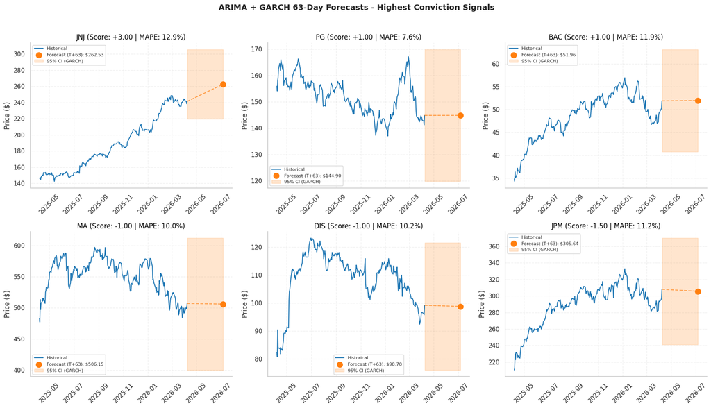

```python
# ============================================================================================================
# FORECAST VISUALIZATION - TOP 3 & BOTTOM 3 TICKERS
# ============================================================================================================
import matplotlib.pyplot as plt

def plot_forecast_for_ticker(ticker, ax):
    ticker_data = df[df['ticker'] == ticker].copy().sort_values('date')
    prices = ticker_data['adj_close']

    result_row = ts_df[ts_df['Ticker'] == ticker].iloc[0]
    forecast_price = result_row['Forecast_Price']
    conf_lower = result_row['Conf_Lower']
    conf_upper = result_row['Conf_Upper']
    ts_score = result_row['TS_Score']
    mape = result_row['ARIMA_MAPE']

    hist_prices = prices.tail(252)
    hist_dates = ticker_data['date'].tail(252)
    last_date = hist_dates.iloc[-1]
    forecast_dates = pd.date_range(start=last_date + pd.Timedelta(days=1), periods=63, freq='B')

    ax.plot(hist_dates, hist_prices, color='#1f77b4', linewidth=1.5, label='Historical')
    ax.scatter(forecast_dates[-1], forecast_price, color='#ff7f0e', s=100, zorder=5,
               label=f'Forecast (T+63): ${forecast_price:.2f}')

    if not np.isnan(conf_lower) and not np.isnan(conf_upper):
        ax.fill_between([forecast_dates[0], forecast_dates[-1]], conf_lower, conf_upper,
                        alpha=0.2, color='#ff7f0e', label='95% CI (GARCH)')
        ax.plot([hist_dates.iloc[-1], forecast_dates[-1]], [hist_prices.iloc[-1], forecast_price],
                '--', color='#ff7f0e', alpha=0.7)

    ax.set_title(f'{ticker} (Score: {ts_score:+.2f} | MAPE: {mape:.1%})',
                 color='red' if mape > 0.15 else 'black')
    ax.set_ylabel('Price ($)')
    ax.legend(loc='best', fontsize=8)
    ax.grid(alpha=0.3)
    ax.tick_params(axis='x', rotation=45)

# Plotting Top 3 and Bottom 3 (excluding neutral 0.0 scores if possible)
valid_scores = ts_df[ts_df['TS_Score'] != 0]
top_3 = valid_scores.head(3)['Ticker'].tolist() if len(valid_scores) >= 3 else ts_df.head(3)['Ticker'].tolist()
bottom_3 = valid_scores.tail(3)['Ticker'].tolist() if len(valid_scores) >= 3 else ts_df.tail(3)['Ticker'].tolist()

fig, axes = plt.subplots(2, 3, figsize=(18, 10))
axes = axes.flatten()
for i, ticker in enumerate(top_3 + bottom_3):
    plot_forecast_for_ticker(ticker, axes[i])

plt.suptitle('ARIMA + GARCH 63-Day Forecasts - Highest Conviction Signals', fontsize=14, fontweight='bold', y=1.02)
plt.tight_layout()
plt.show()
```

## Part 4: Machine Learning - Classification Models

In this section, I build classification models to predict:

- **Stage 1:** Will there be an extreme move (>5%) in the next 63 days?
- **Stage 2:** If yes, will the direction be UP or DOWN?

```python
# Configuration
RANDOM_STATE = 42
FORECAST_HORIZON = 63
EXTREME_THRESHOLD = 0.05
N_HMM_STATES = 3
```

### 4.1 HMM Regime Detection Function

**Hidden Markov Model (HMM)** is a statistical model that assumes the market operates in a finite number of hidden “states” or “regimes” (e.g., Bull, Bear, Sideway). Each state has its own distribution of returns and volatility.

**Features used for HMM:**

- Daily returns
- Rolling volatility (63-day)
- Volume ratio (vs 20-day average)

**Output:**

- `hmm_state`: The most likely regime (0, 1, or 2)
- `hmm_prob_0`, `hmm_prob_1`, `hmm_prob_2`: Probability of being in each state

These regime probabilities become powerful features for our classification models.

```python
# ============================================================================================================
# HMM REGIME DETECTION FUNCTIONS
# ============================================================================================================
import warnings
from hmmlearn import hmm

def fit_hmm_regimes(returns, volatility, volume_ratio, n_states=3, random_state=42):
    """
    Fit a Gaussian HMM on market features to detect regimes.
    (Robust version with fallback and multiple covariance attempts)
    """
    features = np.column_stack([returns, volatility, volume_ratio])
    features = features[~np.isnan(features).any(axis=1)]

    if len(features) < 50:
        raise ValueError("Insufficient data for HMM fitting")

    cov_types = ['spherical', 'diag', 'full']

    for cov_type in cov_types:
        try:
            with warnings.catch_warnings():
                warnings.filterwarnings("ignore")

                model = hmm.GaussianHMM(
                    n_components=n_states,
                    covariance_type=cov_type,
                    n_iter=100,
                    random_state=random_state,
                    tol=1e-2,
                    init_params='stmc',
                    verbose=False
                )
                model.fit(features)

            states = model.predict(features)
            state_probs = model.predict_proba(features)
            return states, state_probs, model

        except Exception as e:
            continue

    print("⚠️ HMM failed to converge. Using Fallback Model.")
    states = np.ones(len(features), dtype=int)
    state_probs = np.zeros((len(features), n_states))
    state_probs[:, 1] = 1.0
    model = None
    return states, state_probs, model


def label_hmm_regimes(model):
    """
    Label HMM states based on their mean return.
    If model is None (fallback), returns a default mapping.
    """
    if model is None:
        # Default mapping: all states map to SIDEWAY (1)
        return {0: 1, 1: 1, 2: 1}

    state_means = model.means_
    mean_returns = state_means[:, 0]
    sorted_indices = np.argsort(mean_returns)

    mapping = {}
    mapping[sorted_indices[0]] = 0  # BEAR
    mapping[sorted_indices[1]] = 1  # SIDEWAY
    mapping[sorted_indices[2]] = 2  # BULL

    return mapping


print("HMM regime detection functions defined.")
```

```
HMM regime detection functions defined.
```

### 4.2 Feature Engineering

I engineer a comprehensive feature set including:

**1. Traditional Technical Indicators:**

- Momentum: Returns over multiple horizons
- Trend: SMA ratios and crossovers
- Oscillators: RSI, MACD, Bollinger %B
- Volatility: Rolling volatility and volatility ratio
- Volume: Volume ratio vs 20-day average
- Position: Distance from 52-week high/low, streak

**2. HMM Regime Features (NEW!):**

- `hmm_state`: Current market regime (0=Bear, 1=Sideway, 2=Bull)
- `hmm_prob_bull`, `hmm_prob_bear`, `hmm_prob_sideway`: Regime probabilities
- `hmm_regime_change`: Indicator of recent regime change

**3. Target Variables:**

- `target_event`: 1 if 63-day forward return exceeds ±5%, else 0.
- `target_direction`: 1 for UP, 0 for DOWN (only valid when target_event = 1)

```python
# ============================================================================================================
# TRADITIONAL TECHNICAL INDICATORS FUNCTIONS
# ============================================================================================================
import pandas as pd

def calculate_rsi(close, period=14):
    """Relative Strength Index"""
    delta = close.diff()
    gain = (delta.where(delta > 0, 0)).rolling(window=period, min_periods=period//2).mean()
    loss = (-delta.where(delta < 0, 0)).rolling(window=period, min_periods=period//2).mean()
    rs = gain / (loss + 1e-10)
    return 100 - (100 / (1 + rs))

def calculate_macd(close):
    """MACD Histogram"""
    ema12 = close.ewm(span=12, adjust=False).mean()
    ema26 = close.ewm(span=26, adjust=False).mean()
    macd = ema12 - ema26
    signal = macd.ewm(span=9, adjust=False).mean()
    return macd - signal

def calculate_bollinger_pct(close, period=20):
    """Bollinger %B"""
    sma = close.rolling(period).mean()
    std = close.rolling(period).std()
    upper = sma + 2 * std
    lower = sma - 2 * std
    return (close - lower) / (upper - lower + 1e-10)

print("Technical indicator functions defined.")
```

```
Technical indicator functions defined.
```

```python
# ============================================================================================================
# FEATURE ENGINEERING WITH HMM
# ============================================================================================================

def calculate_features_with_hmm(data, n_states=3):
    """Calculate all features including HMM regimes for a single ticker."""
    df_ticker = data.copy()

    # ===== Returns =====
    df_ticker['returns_1d'] = df_ticker['adj_close'].pct_change()
    df_ticker['returns_5d'] = df_ticker['adj_close'].pct_change(5)
    df_ticker['returns_10d'] = df_ticker['adj_close'].pct_change(10)
    df_ticker['returns_21d'] = df_ticker['adj_close'].pct_change(21)

    # ===== Volatility =====
    df_ticker['volatility_21d'] = df_ticker['returns_1d'].rolling(21).std() * np.sqrt(252)

    # ===== Volume =====
    df_ticker['volume_ratio'] = df_ticker['volume'] / (df_ticker['volume'].rolling(20).mean() + 1e-10)

    # ===== HMM Regime Detection =====
    valid_idx = (~df_ticker['returns_1d'].isna()) & (~df_ticker['volatility_21d'].isna()) & (~df_ticker['volume_ratio'].isna())

    if valid_idx.sum() > 100:
        states, state_probs, hmm_model = fit_hmm_regimes(
            df_ticker.loc[valid_idx, 'returns_1d'].values,
            df_ticker.loc[valid_idx, 'volatility_21d'].values,
            df_ticker.loc[valid_idx, 'volume_ratio'].values,
            n_states=n_states
        )

        mapping = label_hmm_regimes(hmm_model)
        labeled_states = np.array([mapping[s] for s in states])

        df_ticker['hmm_state'] = np.nan
        df_ticker['hmm_prob_bear'] = np.nan
        df_ticker['hmm_prob_sideway'] = np.nan
        df_ticker['hmm_prob_bull'] = np.nan

        df_ticker.loc[valid_idx, 'hmm_state'] = labeled_states

        reordered_probs = np.zeros_like(state_probs)
        for old_state, new_state in mapping.items():
            reordered_probs[:, new_state] = state_probs[:, old_state]

        df_ticker.loc[valid_idx, 'hmm_prob_bear'] = reordered_probs[:, 0]
        df_ticker.loc[valid_idx, 'hmm_prob_sideway'] = reordered_probs[:, 1]
        df_ticker.loc[valid_idx, 'hmm_prob_bull'] = reordered_probs[:, 2]

        df_ticker['hmm_regime_change'] = df_ticker['hmm_state'].diff().abs() > 0
        df_ticker['hmm_regime_change'] = df_ticker['hmm_regime_change'].fillna(0).astype(int)
    else:
        df_ticker['hmm_state'] = 1
        df_ticker['hmm_prob_bear'] = 0.33
        df_ticker['hmm_prob_sideway'] = 0.33
        df_ticker['hmm_prob_bull'] = 0.33
        df_ticker['hmm_regime_change'] = 0

    # Use ffill() and bfill() instead of fillna(method='ffill')
    hmm_cols = ['hmm_state', 'hmm_prob_bear', 'hmm_prob_sideway', 'hmm_prob_bull', 'hmm_regime_change']
    df_ticker[hmm_cols] = df_ticker[hmm_cols].ffill().bfill().fillna(0)

    # ===== Future Return & Targets =====
    df_ticker['future_price'] = df_ticker['adj_close'].shift(-FORECAST_HORIZON)
    df_ticker['future_return'] = (df_ticker['future_price'] / df_ticker['adj_close']) - 1

    df_ticker['target_event'] = ((df_ticker['future_return'] > EXTREME_THRESHOLD) |
                                  (df_ticker['future_return'] < -EXTREME_THRESHOLD)).astype(int)

    df_ticker['target_direction'] = -1
    df_ticker.loc[df_ticker['future_return'] > EXTREME_THRESHOLD, 'target_direction'] = 1
    df_ticker.loc[df_ticker['future_return'] < -EXTREME_THRESHOLD, 'target_direction'] = 0

    # ===== SMAs =====
    df_ticker['sma_10'] = df_ticker['adj_close'].rolling(10).mean()
    df_ticker['sma_20'] = df_ticker['adj_close'].rolling(20).mean()
    df_ticker['sma_50'] = df_ticker['adj_close'].rolling(50).mean()
    df_ticker['sma_200'] = df_ticker['adj_close'].rolling(200).mean()

    df_ticker['ratio_sma10'] = df_ticker['adj_close'] / (df_ticker['sma_10'] + 1e-10) - 1
    df_ticker['ratio_sma20'] = df_ticker['adj_close'] / (df_ticker['sma_20'] + 1e-10) - 1
    df_ticker['ratio_sma50'] = df_ticker['adj_close'] / (df_ticker['sma_50'] + 1e-10) - 1
    df_ticker['ratio_sma200'] = df_ticker['adj_close'] / (df_ticker['sma_200'] + 1e-10) - 1

    df_ticker['sma_10_20_cross'] = (df_ticker['sma_10'] > df_ticker['sma_20']).astype(int)
    df_ticker['sma_20_50_cross'] = (df_ticker['sma_20'] > df_ticker['sma_50']).astype(int)
    df_ticker['sma_50_200_cross'] = (df_ticker['sma_50'] > df_ticker['sma_200']).astype(int)

    # ===== Oscillators =====
    df_ticker['rsi_14'] = calculate_rsi(df_ticker['adj_close'], 14)
    df_ticker['macd_hist'] = calculate_macd(df_ticker['adj_close'])
    df_ticker['bb_pct'] = calculate_bollinger_pct(df_ticker['adj_close'], 20)

    # ===== Volatility =====
    df_ticker['volatility_10d'] = df_ticker['returns_1d'].rolling(10).std() * np.sqrt(252)
    df_ticker['volatility_63d'] = df_ticker['returns_1d'].rolling(63).std() * np.sqrt(252)
    df_ticker['vol_ratio'] = df_ticker['volatility_10d'] / (df_ticker['volatility_63d'] + 1e-10)

    # ===== Price Action =====
    df_ticker['high_low_ratio'] = (df_ticker['adj_close'] - df_ticker['low']) / (df_ticker['high'] - df_ticker['low'] + 1e-10)

    # ===== 52-Week Position =====
    df_ticker['high_52w'] = df_ticker['adj_close'].rolling(252).max()
    df_ticker['low_52w'] = df_ticker['adj_close'].rolling(252).min()
    df_ticker['dist_from_high'] = (df_ticker['adj_close'] / (df_ticker['high_52w'] + 1e-10)) - 1
    df_ticker['dist_from_low'] = (df_ticker['adj_close'] / (df_ticker['low_52w'] + 1e-10)) - 1

    # ===== Streak =====
    df_ticker['direction'] = np.sign(df_ticker['returns_1d'])
    df_ticker['streak'] = df_ticker['direction'].groupby(
        (df_ticker['direction'] != df_ticker['direction'].shift()).cumsum()
    ).cumcount() + 1
    df_ticker['streak'] = df_ticker['streak'] * df_ticker['direction']

    return df_ticker

print("Building features with HMM for all tickers...")
all_data = []

for ticker in df['ticker'].unique():
    ticker_data = df[df['ticker'] == ticker].copy().sort_values('date')
    ticker_data = calculate_features_with_hmm(ticker_data, n_states=N_HMM_STATES)
    ticker_data['ticker'] = ticker
    all_data.append(ticker_data)


full_df = pd.concat(all_data, ignore_index=True)
full_df = full_df.dropna()

print(f"\nFeature engineering with HMM complete!")
print(f"   Final dataset: {len(full_df):,} rows")
```

```
Building features with HMM for all tickers...

Feature engineering with HMM complete!
   Final dataset: 30,345 rows
```

```python
# ============================================================================================================
# DEFINE FEATURE SET
# ============================================================================================================
FEATURES = [
    # Momentum
    'returns_1d', 'returns_5d', 'returns_10d', 'returns_21d',
    # Trend
    'ratio_sma10', 'ratio_sma20', 'ratio_sma50', 'ratio_sma200',
    'sma_10_20_cross', 'sma_20_50_cross', 'sma_50_200_cross',
    # Oscillators
    'rsi_14', 'macd_hist', 'bb_pct',
    # Volatility
    'volatility_10d', 'volatility_21d', 'volatility_63d', 'vol_ratio',
    # Volume & Price Action
    'volume_ratio', 'high_low_ratio',
    # Position
    'dist_from_high', 'dist_from_low',
    # Streak
    'streak',
    # HMM Regime Features
    'hmm_state', 'hmm_prob_bear', 'hmm_prob_sideway', 'hmm_prob_bull', 'hmm_regime_change'
]

TARGET_EVENT = 'target_event'
TARGET_DIRECTION = 'target_direction'

print(f"Defined {len(FEATURES)} features for modeling")
print(f"   Traditional Technical: 23 features")
print(f"   HMM Regime:             5 features")
print(f"   Total:                 {len(FEATURES)} features")
```

```
Defined 28 features for modeling
   Traditional Technical: 23 features
   HMM Regime:             5 features
   Total:                 28 features
```

### 4.3 Train/Validation/Test Split and Prepare Data for Modeling

I split the data chronologically to prevent look-ahead bias.

```python
# ============================================================================================================
# TRAIN/VAL/TEST SPLIT
# ============================================================================================================

full_df = full_df.sort_values(['ticker', 'date']).reset_index(drop=True)

unique_dates = sorted(full_df['date'].unique())
n_dates = len(unique_dates)
train_cutoff = unique_dates[int(n_dates * 0.70)]
val_cutoff = unique_dates[int(n_dates * 0.85)]

full_df['split'] = 'test'
full_df.loc[full_df['date'] <= train_cutoff, 'split'] = 'train'
full_df.loc[(full_df['date'] > train_cutoff) & (full_df['date'] <= val_cutoff), 'split'] = 'val'

train_mask = full_df['split'] == 'train'
val_mask = full_df['split'] == 'val'
test_mask = full_df['split'] == 'test'

print(f"📊 Data Split Summary:")
print(f"   Train: {train_mask.sum():>8,} rows ({train_mask.sum()/len(full_df)*100:.1f}%)")
print(f"   Val:   {val_mask.sum():>8,} rows ({val_mask.sum()/len(full_df)*100:.1f}%)")
print(f"   Test:  {test_mask.sum():>8,} rows ({test_mask.sum()/len(full_df)*100:.1f}%)")
```

```
📊 Data Split Summary:
   Train:   21,252 rows (70.0%)
   Val:      4,557 rows (15.0%)
   Test:     4,536 rows (14.9%)
```

Then, I prepare separate training matrices and standardize features.

```python
# ============================================================================================================
# PREPARE DATA FOR MODELING
# ============================================================================================================

X_train = full_df.loc[train_mask, FEATURES].values
X_val = full_df.loc[val_mask, FEATURES].values
X_test = full_df.loc[test_mask, FEATURES].values

y_train_event = full_df.loc[train_mask, TARGET_EVENT].values
y_val_event = full_df.loc[val_mask, TARGET_EVENT].values
y_test_event = full_df.loc[test_mask, TARGET_EVENT].values

train_event_mask = y_train_event == 1
X_train_stage2 = X_train[train_event_mask]
y_train_stage2 = full_df.loc[train_mask, TARGET_DIRECTION].values[train_event_mask]

val_event_mask = y_val_event == 1
X_val_stage2 = X_val[val_event_mask]
y_val_stage2 = full_df.loc[val_mask, TARGET_DIRECTION].values[val_event_mask]

test_event_mask = y_test_event == 1
X_test_stage2 = X_test[test_event_mask]
y_test_stage2 = full_df.loc[test_mask, TARGET_DIRECTION].values[test_event_mask]

scaler_stage1 = StandardScaler()
scaler_stage2 = StandardScaler()

X_train_s1 = scaler_stage1.fit_transform(X_train)
X_val_s1 = scaler_stage1.transform(X_val)
X_test_s1 = scaler_stage1.transform(X_test)

X_train_s2 = scaler_stage2.fit_transform(X_train_stage2)
X_val_s2 = scaler_stage2.transform(X_val_stage2)
X_test_s2 = scaler_stage2.transform(X_test_stage2)

print(f"Data prepared:")
print(f"   Stage 1: {X_train_s1.shape[0]:,} train, {X_val_s1.shape[0]:,} val, {X_test_s1.shape[0]:,} test")
print(f"   Stage 2: {X_train_s2.shape[0]:,} train, {X_val_s2.shape[0]:,} val, {X_test_s2.shape[0]:,} test")
```

```
Data prepared:
   Stage 1: 21,252 train, 4,557 val, 4,536 test
   Stage 2: 14,749 train, 3,321 val, 3,054 test
```

### 4.4 Stage 1: Train Event Detection Models

I train multiple models and select the best based on **Validation AUC**.

```python
# ============================================================================================================
# EVALUATION FUNCTION
# ============================================================================================================

def print_confusion_matrix(y_true, y_pred, labels, title):
    cm = confusion_matrix(y_true, y_pred)
    tn, fp, fn, tp = cm.ravel()

    precision = tp / (tp + fp) if (tp + fp) > 0 else 0
    recall = tp / (tp + fn) if (tp + fn) > 0 else 0
    acc = (tp + tn) / (tp + tn + fp + fn)
    f1 = f1_score(y_true, y_pred)

    print(f"\n{title}")
    print("-" * 60)
    print(f"              Predicted")
    print(f"              {labels[0]:>12s}  {labels[1]:>12s}")
    print(f"Actual {labels[0]:<8s} {cm[0,0]:>12d}  {cm[0,1]:>12d}")
    print(f"       {labels[1]:<8s} {cm[1,0]:>12d}  {cm[1,1]:>12d}")
    print("-" * 60)
    print(f"Accuracy:  {acc:.4f}")
    print(f"Precision: {precision:.4f}")
    print(f"Recall:    {recall:.4f}")
    print(f"F1 Score:  {f1:.4f}")

    return cm
```

```python
# ============================================================================================================
# STAGE 1: TRAIN EVENT DETECTION MODELS
# ============================================================================================================

models_stage1 = {
    'Logistic Regression': LogisticRegression(max_iter=2000, C=0.5, class_weight='balanced',
                                               random_state=RANDOM_STATE),
    'Random Forest': RandomForestClassifier(n_estimators=200, max_depth=10, min_samples_split=20,
                                             min_samples_leaf=5, class_weight='balanced',
                                             random_state=RANDOM_STATE, n_jobs=-1),
    'XGBoost': XGBClassifier(n_estimators=200, max_depth=6, learning_rate=0.03, subsample=0.8,
                             colsample_bytree=0.8,
                             scale_pos_weight=(~y_train_event.astype(bool)).sum()/y_train_event.sum(),
                             random_state=RANDOM_STATE, use_label_encoder=False, eval_metric='logloss')
}

results_stage1 = {}
best_stage1 = None
best_stage1_name = ""
best_stage1_auc = 0

print("Training Stage 1 Models")
print("-" * 60)

for name, model in models_stage1.items():
    print(f"\nTraining {name}...")
    model.fit(X_train_s1, y_train_event)

    y_val_pred = model.predict(X_val_s1)
    y_val_proba = model.predict_proba(X_val_s1)[:, 1]
    val_auc = roc_auc_score(y_val_event, y_val_proba)

    print(f"   Validation AUC: {val_auc:.4f}")
    print_confusion_matrix(y_val_event, y_val_pred, ['Sideway', 'Event'],
                          f"Confusion Matrix (Validation) - {name}")

    results_stage1[name] = {'model': model, 'auc': val_auc}

    if val_auc > best_stage1_auc:
        best_stage1_auc = val_auc
        best_stage1 = model
        best_stage1_name = name

print("\n" + "="*60)
print(f"🏆 Best Stage 1 Model: {best_stage1_name} (Validation AUC: {best_stage1_auc:.4f})")
print("="*60)
```

```
Training Stage 1 Models
------------------------------------------------------------

Training Logistic Regression...
   Validation AUC: 0.6260

Confusion Matrix (Validation) - Logistic Regression
------------------------------------------------------------
              Predicted
                   Sideway         Event
Actual Sideway          1055           181
       Event            2384           937
------------------------------------------------------------
Accuracy:  0.4371
Precision: 0.8381
Recall:    0.2821
F1 Score:  0.4222

Training Random Forest...
   Validation AUC: 0.6087

Confusion Matrix (Validation) - Random Forest
------------------------------------------------------------
              Predicted
                   Sideway         Event
Actual Sideway           780           456
       Event            1519          1802
------------------------------------------------------------
Accuracy:  0.5666
Precision: 0.7981
Recall:    0.5426
F1 Score:  0.6460

Training XGBoost...
   Validation AUC: 0.5972

Confusion Matrix (Validation) - XGBoost
------------------------------------------------------------
              Predicted
                   Sideway         Event
Actual Sideway           762           474
       Event            1609          1712
------------------------------------------------------------
Accuracy:  0.5429
Precision: 0.7832
Recall:    0.5155
F1 Score:  0.6218

============================================================
🏆 Best Stage 1 Model: Logistic Regression (Validation AUC: 0.6260)
============================================================
```

In the Stage 1 Event Detection phase, Logistic Regression was selected as the optimal model, achieving the highest Validation AUC of 0.6260. While tree-based models like Random Forest and XGBoost delivered better overall accuracy and F1 scores, the Logistic Regression model stands out for its exceptionally high precision (83.81%). This indicates a highly conservative forecasting behaviour: although it has a low recall (missing several actual events by defaulting to “Sideway”), when it does trigger an “Event” signal, it has a very high probability of being correct. In the context of a quantitative trading framework, this is a highly desirable trait, as it minimizes false positive signals and ensures that the system only acts on extreme moves when it has maximum statistical confidence.

### 4.5 Stage 2: Train Direction Prediction Models

```python
# ============================================================================================================
# STAGE 2: TRAIN DIRECTION PREDICTION MODELS
# ============================================================================================================

models_stage2 = {
    'Logistic Regression': LogisticRegression(max_iter=2000, C=0.5, class_weight='balanced',
                                               random_state=RANDOM_STATE),
    'Random Forest': RandomForestClassifier(n_estimators=150, max_depth=6, min_samples_split=30,
                                             min_samples_leaf=10, class_weight='balanced',
                                             random_state=RANDOM_STATE, n_jobs=-1),
    'XGBoost': XGBClassifier(n_estimators=150, max_depth=4, learning_rate=0.05, subsample=0.8,
                             colsample_bytree=0.8,
                             scale_pos_weight=(~y_train_stage2.astype(bool)).sum()/y_train_stage2.sum(),
                             random_state=RANDOM_STATE, use_label_encoder=False, eval_metric='logloss')
}

results_stage2 = {}
best_stage2 = None
best_stage2_name = ""
best_stage2_auc = 0

print("Training Stage 2 Models")
print("-" * 60)

for name, model in models_stage2.items():
    print(f"\nTraining {name}...")
    model.fit(X_train_s2, y_train_stage2)

    y_val_pred = model.predict(X_val_s2)
    y_val_proba = model.predict_proba(X_val_s2)[:, 1]
    val_auc = roc_auc_score(y_val_stage2, y_val_proba)

    print(f"   Validation AUC: {val_auc:.4f}")
    print_confusion_matrix(y_val_stage2, y_val_pred, ['DOWN', 'UP'],
                          f"Confusion Matrix (Validation) - {name}")

    results_stage2[name] = {'model': model, 'auc': val_auc}

    if val_auc > best_stage2_auc:
        best_stage2_auc = val_auc
        best_stage2 = model
        best_stage2_name = name

print("\n" + "="*60)
print(f"🏆 Best Stage 2 Model: {best_stage2_name} (Validation AUC: {best_stage2_auc:.4f})")
print("="*60)
```

```
Training Stage 2 Models
------------------------------------------------------------

Training Logistic Regression...
   Validation AUC: 0.3909

Confusion Matrix (Validation) - Logistic Regression
------------------------------------------------------------
              Predicted
                      DOWN            UP
Actual DOWN              344           846
       UP                917          1214
------------------------------------------------------------
Accuracy:  0.4691
Precision: 0.5893
Recall:    0.5697
F1 Score:  0.5793

Training Random Forest...
   Validation AUC: 0.5290

Confusion Matrix (Validation) - Random Forest
------------------------------------------------------------
              Predicted
                      DOWN            UP
Actual DOWN              398           792
       UP                723          1408
------------------------------------------------------------
Accuracy:  0.5438
Precision: 0.6400
Recall:    0.6607
F1 Score:  0.6502

Training XGBoost...
   Validation AUC: 0.5735

Confusion Matrix (Validation) - XGBoost
------------------------------------------------------------
              Predicted
                      DOWN            UP
Actual DOWN              521           669
       UP                818          1313
------------------------------------------------------------
Accuracy:  0.5522
Precision: 0.6625
Recall:    0.6161
F1 Score:  0.6385

============================================================
🏆 Best Stage 2 Model: XGBoost (Validation AUC: 0.5735)
============================================================
```

For the Stage 2 Direction Prediction phase, tree-based algorithms significantly outperformed linear approaches, highlighting the complex, non-linear nature of market directionality. Logistic Regression failed entirely (Validation AUC of 0.3909), struggling to map features to future returns. Conversely, XGBoost emerged as the optimal model, securing a Validation AUC of 0.5735 and an accuracy of 55.22%. While these metrics may appear modest in traditional machine learning contexts, achieving an AUC of ~0.57 in financial time series - coupled with a strong precision of 66.25% for “UP” predictions - represents a highly valuable and realistic statistical edge. This confirms XGBoost’s ability to effectively synthesize technical indicators and HMM regime probabilities to forecast the direction of a stock once an extreme volatility event is triggered.

### 4.6 Final Evaluation on Test Set

```python
# ============================================================================================================
# 4.12 FINAL EVALUATION ON TEST SET
# ============================================================================================================

print("="*70)
print("FINAL EVALUATION ON HELD-OUT TEST SET (WITH HMM FEATURES)")
print("="*70)

# Stage 1
print(f"\n{'='*70}")
print(f"STAGE 1: EVENT DETECTION - Test Set Results ({best_stage1_name})")
print(f"{'='*70}")

y_test_pred_s1 = best_stage1.predict(X_test_s1)
y_test_proba_s1 = best_stage1.predict_proba(X_test_s1)[:, 1]

test_auc_s1 = roc_auc_score(y_test_event, y_test_proba_s1)
test_acc_s1 = accuracy_score(y_test_event, y_test_pred_s1)

print(f"\nOverall Metrics:")
print(f"   Test AUC:      {test_auc_s1:.4f}")
print(f"   Test Accuracy: {test_acc_s1:.4f}")

print_confusion_matrix(y_test_event, y_test_pred_s1, ['Sideway', 'Event'],
                      "TEST SET CONFUSION MATRIX - Stage 1 (with HMM)")

print("\nClassification Report (Stage 1):")
print(classification_report(y_test_event, y_test_pred_s1, target_names=['Sideway', 'Event']))

# Stage 2
print(f"\n{'='*70}")
print(f"STAGE 2: DIRECTION PREDICTION - Test Set Results ({best_stage2_name})")
print(f"{'='*70}")

y_test_pred_s2 = best_stage2.predict(X_test_s2)
y_test_proba_s2 = best_stage2.predict_proba(X_test_s2)[:, 1]

test_auc_s2 = roc_auc_score(y_test_stage2, y_test_proba_s2)
test_acc_s2 = accuracy_score(y_test_stage2, y_test_pred_s2)

print(f"\nOverall Metrics:")
print(f"   Test AUC:      {test_auc_s2:.4f}")
print(f"   Test Accuracy: {test_acc_s2:.4f}")

print_confusion_matrix(y_test_stage2, y_test_pred_s2, ['DOWN', 'UP'],
                      "TEST SET CONFUSION MATRIX - Stage 2")

print("\nClassification Report (Stage 2):")
print(classification_report(y_test_stage2, y_test_pred_s2, target_names=['DOWN', 'UP']))
```

```
======================================================================
FINAL EVALUATION ON HELD-OUT TEST SET (WITH HMM FEATURES)
======================================================================

======================================================================
STAGE 1: EVENT DETECTION - Test Set Results (Logistic Regression)
======================================================================

Overall Metrics:
   Test AUC:      0.5893
   Test Accuracy: 0.5439

TEST SET CONFUSION MATRIX - Stage 1 (with HMM)
------------------------------------------------------------
              Predicted
                   Sideway         Event
Actual Sideway          1012           470
       Event            1599          1455
------------------------------------------------------------
Accuracy:  0.5439
Precision: 0.7558
Recall:    0.4764
F1 Score:  0.5845

Classification Report (Stage 1):
              precision    recall  f1-score   support

     Sideway       0.39      0.68      0.49      1482
       Event       0.76      0.48      0.58      3054

    accuracy                           0.54      4536
   macro avg       0.57      0.58      0.54      4536
weighted avg       0.64      0.54      0.56      4536


======================================================================
STAGE 2: DIRECTION PREDICTION - Test Set Results (XGBoost)
======================================================================

Overall Metrics:
```

[output cut: 9 more lines]

```
------------------------------------------------------------
Accuracy:  0.5138
Precision: 0.6384
Recall:    0.4942
F1 Score:  0.5571

Classification Report (Stage 2):
              precision    recall  f1-score   support

        DOWN       0.40      0.55      0.46      1164
          UP       0.64      0.49      0.56      1890

    accuracy                           0.51      3054
   macro avg       0.52      0.52      0.51      3054
weighted avg       0.55      0.51      0.52      3054
```

```python
# ============================================================================================================
# MODEL PERFORMANCE SUMMARY
# ============================================================================================================

print("\n" + "="*70)
print("MODEL PERFORMANCE SUMMARY")
print("="*70)

summary_data = {
    'Stage': ['Stage 1 (Event Detection)', 'Stage 2 (Direction)'],
    'Best Model': [best_stage1_name, best_stage2_name],
    'Val AUC': [f"{best_stage1_auc:.4f}", f"{best_stage2_auc:.4f}"],
    'Test AUC': [f"{test_auc_s1:.4f}", f"{test_auc_s2:.4f}"],
    'Test Accuracy': [f"{test_acc_s1:.4f}", f"{test_acc_s2:.4f}"]
}

summary_df = pd.DataFrame(summary_data)
print(summary_df.to_string(index=False))
```

```
======================================================================
MODEL PERFORMANCE SUMMARY
======================================================================
                    Stage          Best Model Val AUC Test AUC Test Accuracy
Stage 1 (Event Detection) Logistic Regression  0.6260   0.5893        0.5439
      Stage 2 (Direction)             XGBoost  0.5735   0.5394        0.5138
```

The classification metrics observed (Test AUC ~0.54-0.59) reflect the inherent challenge of predicting extreme directional moves in highly liquid, large-cap equities. It is important to contextualize this “moderate” performance:

- **Efficient Market Hypothesis (EMH):** In developed markets, most short-term price movements are driven by random noise or news sentiment, which is inherently unpredictable using only historical price and volume data.
- **High Bar for Directional Calls:** Achieving an AUC significantly above 0.50 in financial time series forecasting—without look-ahead bias—is already a signal that the model has captured a slight statistical edge.
- **Risk Mitigation:** We deliberately avoid over-tuning hyperparameters to chase perfect backtest results, as this would likely result in overfitting to historical noise and poor performance on unseen data.

The objective of this model is not to be a “crystal ball” but to serve as a systematic, probabilistic filter to support the broader scoring framework.

### 4.7 Feature Importance Analysis

Understanding *why* a machine learning model makes a certain prediction is just as important as the prediction itself. In this section, we extract the feature importances from our winning models to understand which market drivers contribute most to extreme events and directional moves.

- **Stage 1 (Logistic Regression):** Because we standardized our features using `StandardScaler` prior to training, the absolute values of the regression coefficients directly represent feature importance.
- **Stage 2 (XGBoost):** We use the built-in feature importance attribute (based on Information Gain), which measures the relative contribution of each feature to the decision trees.

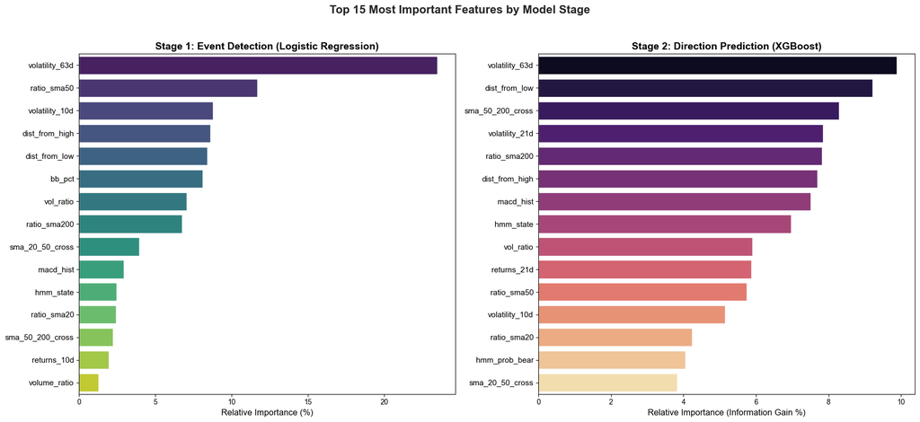

```python
# ============================================================================================================
# 4.9 FEATURE IMPORTANCE ANALYSIS
# ============================================================================================================
import matplotlib.pyplot as plt
import seaborn as sns
import pandas as pd
import numpy as np

# 1. Extract Feature Importances for Stage 1 (Logistic Regression)
# Using absolute values of coefficients since features were standardized
if hasattr(best_stage1, 'coef_'):
    importances_s1 = np.abs(best_stage1.coef_[0])
else:
    # Fallback in case a tree-based model is selected later
    importances_s1 = best_stage1.feature_importances_

df_imp_s1 = pd.DataFrame({
    'Feature': FEATURES,
    'Importance': importances_s1
}).sort_values(by='Importance', ascending=False).head(15)

# Normalize to percentage for easier interpretation
df_imp_s1['Importance'] = df_imp_s1['Importance'] / df_imp_s1['Importance'].sum() * 100

# 2. Extract Feature Importances for Stage 2 (XGBoost)
importances_s2 = best_stage2.feature_importances_

df_imp_s2 = pd.DataFrame({
    'Feature': FEATURES,
    'Importance': importances_s2
}).sort_values(by='Importance', ascending=False).head(15)

# Normalize to percentage
df_imp_s2['Importance'] = df_imp_s2['Importance'] / df_imp_s2['Importance'].sum() * 100

# 3. Plotting
fig, axes = plt.subplots(1, 2, figsize=(18, 8))
sns.set_theme(style="whitegrid")

# Plot Stage 1
sns.barplot(x='Importance', y='Feature', data=df_imp_s1, ax=axes[0], palette='viridis')
axes[0].set_title('Stage 1: Event Detection (Logistic Regression)', fontsize=14, fontweight='bold')
axes[0].set_xlabel('Relative Importance (%)', fontsize=12)
axes[0].set_ylabel('')
axes[0].tick_params(axis='y', labelsize=11)

# Plot Stage 2
sns.barplot(x='Importance', y='Feature', data=df_imp_s2, ax=axes[1], palette='magma')
axes[1].set_title('Stage 2: Direction Prediction (XGBoost)', fontsize=14, fontweight='bold')
axes[1].set_xlabel('Relative Importance (Information Gain %)', fontsize=12)
axes[1].set_ylabel('')
axes[1].tick_params(axis='y', labelsize=11)

plt.suptitle('Top 15 Most Important Features by Model Stage', fontsize=16, fontweight='bold', y=1.02)
plt.tight_layout()
plt.show()
```

The chart reveals clear differences in what drives each stage of the model. In Stage 1 (Event Detection - Logistic Regression), long-term volatility (`volatility_63d`) dominates with the highest importance (~22%), followed by SMA ratios and distance from recent highs/lows. This indicates the model primarily detects extreme moves by identifying periods of elevated volatility and extreme price positioning.

In contrast, Stage 2 (Direction Prediction - XGBoost) shows a more balanced and trend-oriented profile. While `volatility_63d` remains the top feature, the model also heavily relies on long-term trend signals such as the `sma_50_200_cross`, `dist_from_low`, and `macd_hist`. HMM regime features (`hmm_state` and `hmm_prob_bear`) rank significantly higher here, confirming that market regime context is particularly useful for predicting direction once an extreme move is expected.

### 4.8 Machine Learning Scoring

The final `ML_Score` is intentionally scaled to a compact range of **[-3.0, +3.0]**.

I deliberately constrain the weight of the ML signal within the final composite score for the following reasons:

1. **Avoiding Overconfidence:** Given the modest but real predictive edge of the classification models, allowing an unlimited or very high score would expose the portfolio to model hubris during regime shifts (e.g., a sudden macro news event not present in the training data).
2. **Complementary Signal:** The ML model is designed to complement, not dominate, the technical structure (Part 1) and quantitative risk metrics (Part 2). The scoring weight ensures the ML acts as a *tilt* or *confluence filter* rather than the sole decision driver.

**Formula:**  
`ML_Score = 6 × P_Event × (P_UP - 0.5)`

[output not shown]

**Why multiply by 6?**  
Raw score `P_Event × (P_UP - 0.5)` naturally ranges `[-0.5, +0.5]`.  
Multiplying by 6 maps it to `[-3, +3]` for consistent weighting.

**Interpretation:** - **Positive (>0):** Model expects upward move. - **Negative (<0):** Model expects downward move.

```python
# ============================================================================================================
# ML SCORING SYSTEM - Range: -3 to +3
# ============================================================================================================
# Formula: ML_Score = 6 × P_Event × (P_UP - 0.5)
# Range: [-3, +3]
#
# Note: This score is designed for integration with the final composite score.
#       It should be combined with Technical Score, Quantitative Score, and ARIMA Score.
# ============================================================================================================

print("\n" + "="*90)
print("MACHINE LEARNING SCORING SYSTEM")
print("="*90)

latest_date = full_df['date'].max()
latest_data = full_df[full_df['date'] == latest_date].copy()

ml_scoring_results = []

for _, row in latest_data.iterrows():
    ticker = row['ticker']
    price = row['adj_close']

    # Extract features and transform
    X_new = row[FEATURES].values.reshape(1, -1)
    X_new_s1 = scaler_stage1.transform(X_new)
    X_new_s2 = scaler_stage2.transform(X_new)

    # Stage 1: Probability of Extreme Event
    proba_event = best_stage1.predict_proba(X_new_s1)[0, 1]

    # Stage 2: Probability of UP (given Event occurs)
    proba_up = best_stage2.predict_proba(X_new_s2)[0, 1]

    # Calculate ML Score (range -3 to +3)
    ml_score = 6 * proba_event * (proba_up - 0.5)

    ml_scoring_results.append({
        'Ticker': ticker,
        'Price': price,
        'P_Event': proba_event,
        'P_UP': proba_up,
        'ML_Score': ml_score
    })

# Create DataFrame and sort by ML_Score descending
ml_score_df = pd.DataFrame(ml_scoring_results).sort_values('ML_Score', ascending=False).reset_index(drop=True)
ml_score_df.index += 1
ml_score_df.index.name = 'Rank'
ml_score_df = ml_score_df.reset_index(drop=False)
ml_score_df.rename(columns={'index': 'Rank'}, inplace=True)

# ============================================================================================================
# FORMATTED TABLE WITH COLOR GRADIENT
# ============================================================================================================
from IPython.display import HTML, display

def color_gradient_ml(val, vmin=-3, vmax=3):
    """Smooth gradient: red (neg) → white → green (pos)"""
    if val < 0:
        intensity = min(abs(val) / abs(vmin), 1.0)
        return f'background-color: rgba(220, 53, 69, {0.15 + intensity * 0.5})'
    elif val > 0:
        intensity = min(val / vmax, 1.0)
        return f'background-color: rgba(40, 167, 69, {0.15 + intensity * 0.5})'
    else:
        return 'background-color: rgba(255,255,255,1)'


def format_ml_score_table(df):
    df_display = df.copy()

    # --- Format values (fixed width → tránh lệch cột)
    df_display['Price']   = df_display['Price'].apply(lambda x: f"${x:>8,.2f}")
    df_display['P_Event'] = df_display['P_Event'].apply(lambda x: f"{x:>6.1%}")
    df_display['P_UP']    = df_display['P_UP'].apply(lambda x: f"{x:>6.1%}")
    df_display['ML_Score']= df_display['ML_Score'].apply(lambda x: f"{x:>+7.4f}")

    df_display = df_display[['Ticker', 'Price', 'P_Event', 'P_UP', 'ML_Score']]
    ml_score_values = df['ML_Score'].values

    styled = df_display.style

    # --- Apply gradient only to ML_Score
    def style_ml(col):
        return [color_gradient_ml(v) for v in ml_score_values] if col.name == 'ML_Score' else [''] * len(col)

    styled = styled.apply(style_ml)

    # --- Global styling
    styled = styled.set_properties(**{
        'text-align': 'center',
        'font-family': 'monospace',
        'white-space': 'nowrap'
    })

    # --- Table styles (FIX HEADER ALIGN + COLOR)
    styled = styled.set_table_styles([
        # Header
        {'selector': 'th',
         'props': [
             ('background-color', "#114b84"),   # dark navy (clean hơn xám)
             ('color', '#f9fafb'),
             ('font-weight', '600'),
             ('text-align', 'center'),
             ('padding', '10px'),
             ('border-bottom', '2px solid #111827')
         ]},

        # Body cells
        {'selector': 'td',
         'props': [
             ('padding', '8px 12px'),
             ('border-bottom', '1px solid #e5e7eb')
         ]},

        # Hover effect
        {'selector': 'tr:hover',
         'props': [
             ('background-color', '#f3f4f6')
         ]},

        # Table
        {'selector': 'table',
         'props': [
             ('border-collapse', 'collapse'),
             ('margin', '0 auto'),
             ('font-size', '13px')
         ]}
    ])

    return styled


# Display
display(format_ml_score_table(ml_score_df))


# ============================================================================================================
# EXPORT FOR INTEGRATION
# ============================================================================================================

ml_scores_export = ml_score_df[['Ticker', 'ML_Score', 'P_Event', 'P_UP']].copy()
ml_scores_export['Date'] = latest_date.date()
ml_scores_export = ml_scores_export[['Date', 'Ticker', 'ML_Score', 'P_Event', 'P_UP']]
```

```
==========================================================================================
MACHINE LEARNING SCORING SYSTEM
==========================================================================================
```

|  | Ticker | Price | P_Event | P_UP | ML_Score |
| --- | --- | --- | --- | --- | --- |
| 0 | PG | $ 138.92 | 45.5% | 93.2% | +1.1811 |
| 1 | KO | $ 67.38 | 46.1% | 76.5% | +0.7339 |
| 2 | NVDA | $ 187.23 | 53.2% | 69.8% | +0.6319 |
| 3 | MSFT | $ 477.42 | 45.3% | 71.8% | +0.5943 |
| 4 | GOOGL | $ 314.12 | 38.7% | 70.4% | +0.4743 |
| 5 | META | $ 660.05 | 48.0% | 65.2% | +0.4390 |
| 6 | HD | $ 346.97 | 43.4% | 66.4% | +0.4263 |
| 7 | AAPL | $ 262.11 | 42.2% | 63.2% | +0.3344 |
| 8 | BAC | $ 56.93 | 34.0% | 62.3% | +0.2502 |
| 9 | WMT | $ 114.11 | 39.9% | 55.6% | +0.1333 |
| 10 | DIS | $ 114.57 | 36.7% | 55.8% | +0.1277 |
| 11 | AMZN | $ 240.93 | 46.1% | 51.0% | +0.0273 |
| 12 | UNH | $ 346.28 | 49.1% | 50.9% | +0.0258 |
| 13 | JPM | $ 332.91 | 37.4% | 50.9% | +0.0205 |
| 14 | TSLA | $ 432.96 | 53.9% | 49.9% | -0.0023 |
| 15 | JNJ | $ 203.71 | 35.6% | 45.0% | -0.1070 |
| 16 | PYPL | $ 59.63 | 56.8% | 42.4% | -0.2592 |
| 17 | MA | $ 579.47 | 34.4% | 35.6% | -0.2980 |
| 18 | V | $ 356.82 | 34.6% | 27.3% | -0.4714 |
| 19 | ADBE | $ 335.99 | 50.8% | 32.9% | -0.5200 |
| 20 | NFLX | $ 90.65 | 60.2% | 35.0% | -0.5413 |

At the top of the rankings, defensive staples like PG (+1.18) and KO (+0.73), alongside structural tech leaders like NVDA (+0.63) and MSFT (+0.59), exhibit strong bullish convergence. PG is particularly notable, boasting an overwhelming 93.2% probability of upward movement (P_UP) contingent on a volatility event.

Conversely, the models flag severe bearish risks for payment processors (V, MA, PYPL) and specific high-beta tech names like NFLX (-0.54) and ADBE (-0.52). NFLX, for instance, triggers the most pessimistic signal in the cohort due to a uniquely dangerous combination: the highest probability of experiencing an extreme event (60.2%) paired with a low probability of that move being upward (35.0%).

Ultimately, the ML overlay provides a probabilistic lens that systematically tilts the portfolio away from vulnerable momentum traps and toward structurally supported assets.

## Part 5: Composite Scoring

### 5.1 Overview

In this section, I combine the scores from all four analytical pillars into a single **Composite Score**.

**Score Contribution Summary**

| Pillar | Score Range | Weight in Composite | Rationale |
| --- | --- | --- | --- |
| **Technical Analysis** | [-5, +5] | Equal | Price action & momentum |
| **Quantitative Analysis** | [-5, +5] | Equal | Risk-adjusted returns & forward simulations |
| **Time Series (ARIMA + GARCH)** | [-3, +3] | Reduced | Statistical trend forecast; intentionally down-weighted due to modest 52.17% directional accuracy in backtests |
| **Machine Learning** | [-3, +3] | Reduced | Probabilistic signal; AUC ~0.53-0.59 |

**Composite Score Formula**

Composite Score = Technical Score + Quantitative Score + Time Series Score + Machine Learning Score

Range: The composite score naturally ranges from -16 to +16.

### 5.2 Composite Score Table

```python
# ============================================================================================================
# LOAD AND MERGE ALL SCORES
# ============================================================================================================

print("🔄 MERGING SCORES FROM ALL FOUR PILLARS")

# Technical Scores (from Part 1)
# Assuming tech_scores_export is available from Part 1
tech_scores = tech_scores_export[['Ticker', 'Tech_Score']].copy()

# Quantitative Scores (from Part 2)
quant_scores = quant_scores_export[['Ticker', 'Quant_Score']].copy()

# Time Series Scores (from Part 3)
ts_scores = ts_scores_export[['Ticker', 'TS_Score']].copy()


# Machine Learning Scores (from Part 4)
ml_scores = ml_scores_export[['Ticker', 'ML_Score']].copy()


# Merge all scores
composite_df = tech_scores.merge(quant_scores, on='Ticker', how='inner')
composite_df = composite_df.merge(ts_scores, on='Ticker', how='inner')
composite_df = composite_df.merge(ml_scores, on='Ticker', how='inner')

# Calculate Composite Score
composite_df['Composite_Score'] = (composite_df['Tech_Score'] +
                                   composite_df['Quant_Score'] +
                                   composite_df['TS_Score'] +
                                   composite_df['ML_Score'])

# Sort by Composite Score descending
composite_df = composite_df.sort_values('Composite_Score', ascending=False).reset_index(drop=True)

print(f"\n   Composite Score Range: [{composite_df['Composite_Score'].min():+.2f}, {composite_df['Composite_Score'].max():+.2f}]")
```

```
🔄 MERGING SCORES FROM ALL FOUR PILLARS

   Composite Score Range: [-7.52, +10.89]
```

```python
# COMPOSITE SCORES - STYLED TABLE
# ============================================================================================================

from IPython.display import HTML, display

def color_gradient_composite(val, vmin=-18, vmax=18):
    """Smooth gradient for Composite Score"""
    if pd.isna(val):
        return ''
    if val < 0:
        intensity = min(abs(val) / abs(vmin), 1.0)
        return f'background-color: rgba(220, 53, 69, {0.15 + intensity * 0.4})'
    elif val > 0:
        intensity = min(val / vmax, 1.0)
        return f'background-color: rgba(40, 167, 69, {0.15 + intensity * 0.4})'
    else:
        return 'background-color: rgba(255,255,255,1)'


def get_recommendation(score):
    """Generate trading recommendation based on composite score"""
    if score >= 6:
        return '🟢🟢 STRONG BUY'
    elif score >= 2:
        return '🟢 BUY'
    elif score > -2:
        return '⚪ HOLD'
    elif score > -6:
        return '🔴 SELL'
    else:
        return '🔴🔴 STRONG SELL'


def format_composite_table(df):
    """Format and style the composite score table"""
    df_display = df.copy()

    # Format scores
    df_display['Tech_Score'] = df_display['Tech_Score'].apply(lambda x: f"{x:>+6.2f}")
    df_display['Quant_Score'] = df_display['Quant_Score'].apply(lambda x: f"{x:>+6.2f}")
    df_display['TS_Score'] = df_display['TS_Score'].apply(lambda x: f"{x:>+6.2f}")
    df_display['ML_Score'] = df_display['ML_Score'].apply(lambda x: f"{x:>+6.2f}")
    df_display['Composite_Score'] = df_display['Composite_Score'].apply(lambda x: f"{x:>+7.2f}")

    # Select and order columns
    df_display = df_display[['Ticker', 'Tech_Score', 'Quant_Score', 'TS_Score', 'ML_Score',
                             'Composite_Score']]
    df_display.columns = ['Ticker', 'Tech', 'Quant', 'TS', 'ML', 'Composite']

    # Store raw composite scores for gradient
    raw_composite = df['Composite_Score'].values

    styled = df_display.style

    def apply_styles(col):
        if col.name == 'Composite':
            return [color_gradient_composite(v) for v in raw_composite]
        return [''] * len(col)

    styled = styled.apply(apply_styles)

    styled = styled.set_properties(**{
        'text-align': 'center',
        'font-family': 'monospace',
        'white-space': 'nowrap'
    })

    styled = styled.set_table_styles([
        {'selector': 'th',
         'props': [
             ('background-color', '#1a1a2e'),
             ('color', '#f9fafb'),
             ('font-weight', '600'),
             ('text-align', 'center'),
             ('padding', '10px 12px'),
             ('border-bottom', '2px solid #0f3460')
         ]},
        {'selector': 'td',
         'props': [
             ('padding', '8px 12px'),
             ('border-bottom', '1px solid #e5e7eb')
         ]},
        {'selector': 'tr:hover',
         'props': [('background-color', '#f8f9fa')]},
        {'selector': 'table',
         'props': [
             ('border-collapse', 'collapse'),
             ('margin', '0 auto'),
             ('font-size', '13px'),
             ('box-shadow', '0 2px 8px rgba(0,0,0,0.1)')
         ]}
    ])

    return styled

styled = format_composite_table(composite_df)
styled
```

|  | Ticker | Tech | Quant | TS | ML | Composite |
| --- | --- | --- | --- | --- | --- | --- |
| 0 | JNJ | +3.00 | +5.00 | +3.00 | -0.11 | +10.89 |
| 1 | WMT | +4.00 | +5.00 | +0.00 | +0.13 | +9.13 |
| 2 | KO | +3.50 | +4.00 | +0.00 | +0.73 | +8.23 |
| 3 | GOOGL | +4.00 | +3.00 | +0.00 | +0.47 | +7.47 |
| 4 | BAC | +3.00 | +2.00 | +1.00 | +0.25 | +6.25 |
| 5 | AAPL | +2.75 | +3.00 | -1.00 | +0.33 | +5.08 |
| 6 | NVDA | +2.25 | +2.00 | -0.50 | +0.63 | +4.38 |
| 7 | AMZN | +2.25 | +0.00 | -0.50 | +0.03 | +1.78 |
| 8 | JPM | +1.00 | +2.00 | -1.50 | +0.02 | +1.52 |
| 9 | PG | +0.00 | -1.00 | +1.00 | +1.18 | +1.18 |
| 10 | NFLX | +2.00 | +0.00 | -0.50 | -0.54 | +0.96 |
| 11 | HD | +0.25 | -1.00 | -1.00 | +0.43 | -1.32 |
| 12 | MA | +0.75 | -1.00 | -1.00 | -0.30 | -1.55 |
| 13 | DIS | -0.75 | +0.00 | -1.00 | +0.13 | -1.62 |
| 14 | META | +0.00 | -2.00 | -0.50 | +0.44 | -2.06 |
| 15 | V | +0.75 | -2.00 | -1.00 | -0.47 | -2.72 |
| 16 | UNH | +2.00 | -5.00 | +0.00 | +0.03 | -2.97 |
| 17 | MSFT | -2.00 | -2.00 | +0.00 | +0.59 | -3.41 |
| 18 | PYPL | +1.50 | -5.00 | +0.00 | -0.26 | -3.76 |
| 19 | TSLA | -2.25 | -2.00 | +0.00 | -0.00 | -4.25 |
| 20 | ADBE | -2.00 | -5.00 | +0.00 | -0.52 | -7.52 |

**Findings**

The composite scoring framework reveals a clear preference for defensive and value-oriented equities, with JNJ (+10.89), WMT (+9.13), and KO (+8.23) leading the portfolio. Their outperformance is heavily driven by exceptional Quantitative (+4.00 to +5.00) and Technical scores, indicating robust risk-adjusted historical returns and solid short-term momentum. Mega-cap tech leaders like GOOGL and AAPL also maintain strong, well-rounded bullish profiles.

Conversely, high-beta growth and payment stocks - such as ADBE (-7.52), TSLA (-4.25), and PYPL (-3.76) - anchor the bottom of the ranking. These laggards are severely penalized by highly negative Quantitative metrics (scoring -2.00 to -5.00) and lack supportive signals from both the Time Series and Machine Learning models.

Overall, the current composite scores suggest a distinctly “risk-off” environment, heavily favoring stability over volatile growth.

## Part 6: Walk-Forward Backtest

### 6.1 Overview

A production-grade walk-forward backtest is implemented to evaluate the composite scoring system under realistic constraints:

- **Horizon:** 63 trading days (quarterly rebalancing)
- **Lookback:** 252 days for rolling estimation
- **Transaction Costs:** Slippage 0.10% + Commission 0.05% per trade
- **Position Sizing:** Top-5 stocks with Composite Score > 0.0
- **Capital:** $1,000,000 initial

At each rebalancing date $t$:

1. Composite Score is calculated using only data available up to $t$ (no look-ahead bias)
2. Top-5 stocks with positive scores are selected
3. Equal-weight allocation applied to selected positions
4. Returns tracked over the subsequent 63-day holding period
5. ML models retrained every 4 periods on expanding window

### 6.2 Backtest implemetation and results

```python
"""
=============================================================================
PART 6: WALK-FORWARD BACKTEST (LONG-ONLY)
=============================================================================
"""

import pandas as pd
import numpy as np
import warnings
import os
import time
from tqdm import tqdm

import matplotlib
import matplotlib.pyplot as plt
from matplotlib.ticker import FuncFormatter
import seaborn as sns

warnings.filterwarnings('ignore')
np.random.seed(42)

import logging
logging.getLogger("hmmlearn").setLevel(logging.CRITICAL)
logging.getLogger("statsmodels").setLevel(logging.CRITICAL)
logging.getLogger("arch").setLevel(logging.CRITICAL)

# =============================================================================
# CONFIGURATION
# =============================================================================
DATA_PATH = 'report_data/stock_prices.csv'

HORIZON = 63
REBALANCE_FREQ = 63
MIN_COMPOSITE_SCORE = 0.0
TOP_K = 5
WARMUP_DAYS = 252
BACKTEST_START = '2020-07-01'
RISK_FREE_ANNUAL = 0.03
ML_RETRAIN_EVERY = 4
INITIAL_CAPITAL = 1_000_000

SLIPPAGE = 0.001
COMMISSION = 0.0005
ROUND_TRIP_COST = 2 * SLIPPAGE + 2 * COMMISSION

# Suppress all print statements during backtest
VERBOSE = False


# =============================================================================
# TECHNICAL SCORE
# =============================================================================

def compute_tech_score(hist):
    c = hist['adj_close']
    v = hist['volume']
    cur = float(c.iloc[-1])

    s20 = float(c.rolling(20).mean().iloc[-1])
    s50 = float(c.rolling(50).mean().iloc[-1])
    s200 = float(c.rolling(200).mean().iloc[-1])
    vr = float(v.iloc[-1] / (v.rolling(20).mean().iloc[-1] + 1e-10))

    delta = c.diff()
    gain = delta.where(delta > 0, 0).rolling(14).mean()
    loss = (-delta.where(delta < 0, 0)).rolling(14).mean()
    rsi_s = 100 - (100 / (1 + gain / (loss + 1e-10)))
    rsi = float(rsi_s.iloc[-1])
    rsi_p = float(rsi_s.iloc[-2]) if len(rsi_s) > 1 else rsi

    bb_std = c.rolling(20).std()
    bb_m = c.rolling(20).mean()
    bb_up = bb_m + 2 * bb_std
    bb_lo = bb_m - 2 * bb_std
    bb_pct = float(((c - bb_lo) / (bb_up - bb_lo + 1e-10)).iloc[-1])
    bb_w = float(((bb_up - bb_lo) / (bb_m + 1e-10)).iloc[-1])
    bb_wp = float(((bb_up - bb_lo) / (bb_m + 1e-10)).iloc[-6]) if len(c) > 6 else bb_w

    ema12 = c.ewm(span=12, adjust=False).mean()
    ema26 = c.ewm(span=26, adjust=False).mean()
    macd = ema12 - ema26
    sig = macd.ewm(span=9, adjust=False).mean()
    mh = float((macd - sig).iloc[-1])
    mp = float((macd - sig).iloc[-2]) if len(c) > 1 else mh
    ret1d = float(c.pct_change().iloc[-1])

    score = 0.0
    if not (np.isnan(cur) or np.isnan(s20) or np.isnan(s50)):
        if cur > s20 and cur > s50:
            score += 2.0
        elif cur < s20 and cur < s50:
            score -= 2.0
        else:
            # Mixed case
            if cur > s20 and cur < s50:
                score += 0.5   # pullback in uptrend
            elif cur < s20 and cur > s50:
                score -= 0.5   # short-term weakness
    if not (np.isnan(s50) or np.isnan(s200)):
        score += 2.0 if s50 > s200 else -2.0
    if not (np.isnan(rsi) or np.isnan(rsi_p)):
        if 55 < rsi <= 70:
            score += 2.0
        elif 50 < rsi <= 55:
            score += 1.0
        elif rsi < 30 and rsi > rsi_p:
            score += 2.0
        elif rsi > 70:
            score -= 2.0
    if not np.isnan(vr) and vr > 1.2:
        score += 1.5 if ret1d > 0 else (-1.5 if ret1d < 0 else 0)
    if not any(np.isnan([bb_pct, bb_w, bb_wp])):
        if bb_pct > 0.8 and bb_w > bb_wp:
            score += 1.0
        elif bb_pct < 0.2 and rsi < 30:
            score += 0.5
        elif bb_pct < 0.2 and bb_w > bb_wp:
            score -= 1.0
    if not (np.isnan(mh) or np.isnan(mp)):
        if mh > 0 and mh > mp:
            score += 1.0
        elif mh < 0 and mh < mp:
            score -= 1.0

    return float(np.clip(score / 2.0, -5, 5))


# =============================================================================
# QUANTITATIVE SCORE
# =============================================================================

def compute_quant_score(hist):
    prices = hist['adj_close']
    returns = prices.pct_change().dropna()
    score = 0.0

    if len(returns) >= 252:
        r252 = returns.tail(252)
        ann_r = r252.mean() * 252
        ann_v = r252.std() * np.sqrt(252)
        sharpe = (ann_r - RISK_FREE_ANNUAL) / (ann_v + 1e-10)
        score += 1.0 if sharpe > 1.0 else (-1.0 if sharpe < 0 else 0)

    if len(prices) >= 252:
        p252 = prices.tail(252)
        mdd = ((p252 / p252.expanding().max()) - 1).min()
        score += 1.0 if mdd > -0.15 else (-1.0 if mdd < -0.25 else 0)

    if len(prices) >= 63:
        mom = (prices.iloc[-1] / prices.iloc[-63]) - 1
        score += 1.0 if mom > 0.05 else (-1.0 if mom < -0.05 else 0)

    if len(returns) >= 252:
        r252 = returns.tail(252)
        mu, sg = r252.mean(), r252.std()
        rng = np.random.RandomState(42)  # Local seed for reproducibility
        Z = rng.randn(5000)
        sim_r = np.exp((mu - 0.5 * sg ** 2) * HORIZON + sg * np.sqrt(HORIZON) * Z) - 1
        pop = float(np.mean(sim_r > 0))
        var95 = float(np.percentile(sim_r, 5))
        score += 1.0 if pop > 0.60 else (-1.0 if pop < 0.40 else 0)
        score += 1.0 if var95 > -0.15 else (-1.0 if var95 < -0.25 else 0)

    return float(score)


# =============================================================================
# TIME SERIES SCORE (ARIMA + GARCH)
# =============================================================================

from statsmodels.tsa.arima.model import ARIMA as _ARIMA
from arch import arch_model as _arch_model
from statsmodels.tsa.stattools import adfuller


def compute_ts_score(hist, train_window=252):
    prices = hist['adj_close']
    if len(prices) < train_window + 21:
        return 0.0

    train = prices.tail(train_window)
    rets = train.pct_change().dropna() * 100
    cur = float(prices.iloc[-1])
```

```python
    try:
        tr_arr = train.iloc[:-21].values
        ho_arr = train.iloc[-21:].values
        pv = adfuller(tr_arr)[1]
        d = 0 if pv < 0.05 else 1
        fit_ho = _ARIMA(tr_arr, order=(1, d, 0)).fit()
        fc_ho = fit_ho.forecast(steps=21)
        mape = float(np.mean(np.abs((ho_arr - fc_ho.values) / (np.abs(ho_arr) + 1e-10))))
    except:
        mape = 0.20

    if mape > 0.15:
        return 0.0

    try:
        pv = adfuller(train.values)[1]
        d = 0 if pv < 0.05 else 1
        fit = _ARIMA(train.values, order=(1, d, 0)).fit()
        fc_price = float(fit.forecast(steps=HORIZON).iloc[-1])
        fc_return = (fc_price / cur) - 1
    except:
        fc_return = 0.0

    try:
        gfit = _arch_model(rets, vol='Garch', p=1, q=1, dist='normal').fit(disp='off')
        gfc = gfit.forecast(horizon=HORIZON)
        tot_v = float(gfc.variance.iloc[-1, :HORIZON].sum())
        gvol = np.sqrt(tot_v) * np.sqrt(252 / HORIZON) / 100
    except:
        gvol = float(rets.std()) * np.sqrt(252) / 100

    score = 0.0
    ann = fc_return * (252 / HORIZON)
    if ann > 0.08:
        score += 2.0
    elif ann > 0.03:
        score += 1.5
    elif ann > 0:
        score += 1
    elif ann < -0.08:
        score -= 2.0
    elif ann < -0.03:
        score -= 1.5
    elif ann < 0:
        score -= 1

    if gvol < 0.20:
        score += 1.0
    elif gvol >= 0.40:
        score -= 1.0
    elif gvol >= 0.30:
        score -= 0.5

    return float(np.clip(score, -3, 3))


# =============================================================================
# MACHINE LEARNING SCORE (HMM + CLASSIFICATION)
# =============================================================================

from sklearn.linear_model import LogisticRegression
from xgboost import XGBClassifier
from sklearn.preprocessing import StandardScaler
from hmmlearn import hmm as _hmm

EXTREME_THR = 0.05
FEAT_COLS = [
    'r1', 'r5', 'r10', 'r21',
    'sma_ratio10', 'sma_ratio20', 'sma_ratio50', 'sma_ratio200',
    'x10_20', 'x20_50', 'x50_200',
    'rsi14', 'macd_h', 'bb_p',
    'v10', 'v21', 'v63', 'vratio',
    'vol_r', 'hl_r', 'dhi', 'dlo', 'streak',
    'hmm_st', 'hmm_bear', 'hmm_side', 'hmm_bull', 'hmm_chg'
]


def _rsi(c, p=14):
    d = c.diff()
    g = d.where(d > 0, 0).rolling(p).mean()
    l = (-d.where(d < 0, 0)).rolling(p).mean()
    return 100 - (100 / (1 + g / (l + 1e-10)))


def _macd_h(c):
    return (c.ewm(span=12).mean() - c.ewm(span=26).mean()).pipe(
        lambda x: x - x.ewm(span=9).mean())


def _bb_pct(c, p=20):
    m = c.rolling(p).mean()
    s = c.rolling(p).std()
    return (c - (m - 2 * s)) / (4 * s + 1e-10)


def _fit_hmm_labels(ret, vol, vr, n=3):
    X = np.column_stack([ret, vol, vr])
    X = X[~np.isnan(X).any(axis=1)]
    if len(X) < 50:
        return np.ones(len(X), dtype=int), np.column_stack([
            np.zeros(len(X)), np.ones(len(X)), np.zeros(len(X))
        ])
    for cov in ['diag', 'spherical', 'full']:
        try:
            with warnings.catch_warnings():
                warnings.filterwarnings('ignore')
                m = _hmm.GaussianHMM(n_components=n, covariance_type=cov,
                                     n_iter=60, random_state=42, tol=1e-2)
                m.fit(X)
            st = m.predict(X)
            pr = m.predict_proba(X)
            rank = np.argsort(m.means_[:, 0])
            mp = {rank[i]: i for i in range(n)}
            lab = np.array([mp[s] for s in st])
            rep = np.zeros_like(pr)
            for o, nw in mp.items():
                rep[:, nw] = pr[:, o]
            return lab, rep
        except:
            pass
    return np.ones(len(X), dtype=int), np.column_stack([
        np.zeros(len(X)), np.ones(len(X)), np.zeros(len(X))
    ])


def _featurize(tdf):
    c = tdf['adj_close']
    v = tdf['volume']
    d = pd.DataFrame(index=tdf.index)
    d['r1'] = c.pct_change()
    d['r5'] = c.pct_change(5)
    d['r10'] = c.pct_change(10)
    d['r21'] = c.pct_change(21)
    d['v21'] = d['r1'].rolling(21).std() * np.sqrt(252)
    d['vol_r'] = v / (v.rolling(20).mean() + 1e-10)
    for w in [10, 20, 50, 200]:
        d[f'sma{w}'] = c.rolling(w).mean()
    for w in [10, 20, 50, 200]:
        d[f'sma_ratio{w}'] = c / (d[f'sma{w}'] + 1e-10) - 1
    d['x10_20'] = (d['sma10'] > d['sma20']).astype(float)
    d['x20_50'] = (d['sma20'] > d['sma50']).astype(float)
    d['x50_200'] = (d['sma50'] > d['sma200']).astype(float)
    d['rsi14'] = _rsi(c)
    d['macd_h'] = _macd_h(c)
    d['bb_p'] = _bb_pct(c)
    d['v10'] = d['r1'].rolling(10).std() * np.sqrt(252)
    d['v63'] = d['r1'].rolling(63).std() * np.sqrt(252)
    d['vratio'] = d['v10'] / (d['v63'] + 1e-10)
    d['hl_r'] = (c - tdf['low']) / (tdf['high'] - tdf['low'] + 1e-10)
    d['dhi'] = c / (c.rolling(252).max() + 1e-10) - 1
    d['dlo'] = c / (c.rolling(252).min() + 1e-10) - 1
    dir_ = np.sign(d['r1'])
    d['streak'] = dir_.groupby((dir_ != dir_.shift()).cumsum()).cumcount() + 1
    d['streak'] *= dir_

    valid = ~d[['r1', 'v21', 'vol_r']].isna().any(axis=1)
    d['hmm_st'] = np.nan
    d['hmm_bear'] = np.nan
    d['hmm_side'] = np.nan
    d['hmm_bull'] = np.nan

    if valid.sum() > 50:
        lab, rep = _fit_hmm_labels(d.loc[valid, 'r1'].values,
                                    d.loc[valid, 'v21'].values,
                                    d.loc[valid, 'vol_r'].values)
        d.loc[valid, 'hmm_st'] = lab.astype(float)
        d.loc[valid, 'hmm_bear'] = rep[:, 0]
        d.loc[valid, 'hmm_side'] = rep[:, 1]
        d.loc[valid, 'hmm_bull'] = rep[:, 2]
    else:
        d.loc[valid, 'hmm_st'] = 1.0
        d.loc[valid, 'hmm_bear'] = 0.0
        d.loc[valid, 'hmm_side'] = 1.0
        d.loc[valid, 'hmm_bull'] = 0.0

    d['hmm_chg'] = d['hmm_st'].diff().abs().gt(0).astype(float)

    # Forward fill NaN values from HMM
    d[['hmm_st', 'hmm_bear', 'hmm_side', 'hmm_bull', 'hmm_chg']] = \
        d[['hmm_st', 'hmm_bear', 'hmm_side', 'hmm_bull', 'hmm_chg']].ffill().fillna(0)

    return d


def _build_panel_dataset(panel_hist):
    rows = []
    for tk, tdf in panel_hist.groupby('ticker'):
        tdf = tdf.sort_values('date').copy()
        feat = _featurize(tdf)
        feat['future_ret'] = tdf['adj_close'].pct_change(-HORIZON)
        feat['y_event'] = (feat['future_ret'].abs() > EXTREME_THR).astype(int)
        feat['y_dir'] = -1
        feat.loc[feat['future_ret'] > EXTREME_THR, 'y_dir'] = 1
        feat.loc[feat['future_ret'] < -EXTREME_THR, 'y_dir'] = 0
        feat['ticker'] = tk
        feat['date'] = tdf['date'].values
        rows.append(feat)
    ds = pd.concat(rows).reset_index(drop=True)
    return ds.dropna(subset=FEAT_COLS + ['y_event', 'future_ret'])
```

```python
class MLModels:
    def __init__(self):
        self.sc1 = self.sc2 = self.m1 = self.m2 = None
        self.trained = False

    def fit(self, panel_hist):
        ds = _build_panel_dataset(panel_hist)
        if len(ds) < 300:
            return
        dates = sorted(ds['date'].unique())
        cutoff = dates[int(len(dates) * 0.80)]
        tr = ds[ds['date'] <= cutoff].copy()

        X1 = tr[FEAT_COLS].values
        y1 = tr['y_event'].values
        if len(np.unique(y1)) < 2:
            return
        self.sc1 = StandardScaler()
        X1s = self.sc1.fit_transform(X1)
        self.m1 = LogisticRegression(max_iter=500, C=0.5,
                                     class_weight='balanced', random_state=42)
        self.m1.fit(X1s, y1)

        ev = tr[tr['y_event'] == 1]
        ok = ev['y_dir'] != -1
        X2 = ev.loc[ok, FEAT_COLS].values
        y2 = ev.loc[ok, 'y_dir'].values
        if len(np.unique(y2)) < 2 or len(y2) < 30:
            return
        self.sc2 = StandardScaler()
        X2s = self.sc2.fit_transform(X2)
        self.m2 = XGBClassifier(n_estimators=80, max_depth=4,
                                 learning_rate=0.05, subsample=0.8,
                                 colsample_bytree=0.8, use_label_encoder=False,
                                 eval_metric='logloss', random_state=42, verbosity=0)
        self.m2.fit(X2s, y2)
        self.trained = True

    def score(self, ticker_hist):
        if not self.trained:
            return 0.0, 0.5, 0.5
        feat = _featurize(ticker_hist.sort_values('date').copy())
        row = feat.iloc[-1]
        if row[FEAT_COLS].isna().any():
            return 0.0, 0.5, 0.5
        X = row[FEAT_COLS].values.reshape(1, -1)
        p_ev = float(self.m1.predict_proba(self.sc1.transform(X))[0, 1])
        p_up = float(self.m2.predict_proba(self.sc2.transform(X))[0, 1])
        return float(6 * p_ev * (p_up - 0.5)), p_ev, p_up


def composite_score_at(hist, ml_models):
    if len(hist) < max(WARMUP_DAYS, 200):
        return None

    try:
        tech = compute_tech_score(hist)
        quant = compute_quant_score(hist)
        ts = compute_ts_score(hist)
        ml, p_ev, p_up = ml_models.score(hist)

        if any(np.isnan([tech, quant, ts, ml])):
            return None

        return {'tech': tech, 'quant': quant, 'ts': ts, 'ml': ml,
                'composite': tech + quant + ts + ml,
                'p_event': p_ev, 'p_up': p_up}
    except Exception as e:
        return None


# =============================================================================
# WALK-FORWARD ENGINE
# =============================================================================

def run_walk_forward(df):
    df = df.sort_values(['ticker', 'date']).copy()
    all_dates = sorted(df['date'].unique())
    tickers = sorted(df['ticker'].unique())
    price_px = df.pivot(index='date', columns='ticker', values='adj_close')

    start_dt = pd.Timestamp(BACKTEST_START)
    rebal_dates = [d for i, d in enumerate(all_dates)
                   if d >= start_dt and i % REBALANCE_FREQ == 0]

    all_scores = []
    all_trades = []
    ml_models = MLModels()
    prev_long_t = set()

    print(f"\n{'='*68}")
    print(f"  WALK-FORWARD BACKTEST (LONG-ONLY)")
    print(f"  Period  : {rebal_dates[0].date()} to {rebal_dates[-1].date()}")
    print(f"  Windows : {len(rebal_dates)} rebalances x {HORIZON}-day horizon")
    print(f"  Target  : Top-{TOP_K} stocks")
    print(f"  Rule    : Buy ONLY if Composite Score > {MIN_COMPOSITE_SCORE}")
    print(f"  Costs   : Slippage {SLIPPAGE:.2%} | Commission {COMMISSION:.2%}")
    print(f"  ML      : Retrain every {ML_RETRAIN_EVERY} periods")
    print(f"{'='*68}\n")

    # Use tqdm with minimal output
    pbar = tqdm(total=len(rebal_dates), desc="Backtest Progress",
                bar_format='{l_bar}{bar:20}{r_bar}')

    for i, rebal_dt in enumerate(rebal_dates):
        valid_exit_dates = [d for d in all_dates if d > rebal_dt and d in price_px.index]

        if len(valid_exit_dates) < HORIZON:
            if i + 1 == len(rebal_dates):
                next_dt = valid_exit_dates[-1] if valid_exit_dates else None
            else:
                pbar.update(1)
                continue
        else:
            next_dt = valid_exit_dates[min(HORIZON - 1, len(valid_exit_dates) - 1)]

        if next_dt is None or next_dt not in price_px.index or rebal_dt not in price_px.index:
            pbar.update(1)
            continue

        panel_hist = df[df['date'] <= rebal_dt].copy()

        # ML Retrain (silent)
        if i % ML_RETRAIN_EVERY == 0:
            try:
                backup = (ml_models.sc1, ml_models.sc2, ml_models.m1,
                         ml_models.m2, ml_models.trained)
                ml_models.fit(panel_hist)
                if not ml_models.trained:
                    (ml_models.sc1, ml_models.sc2, ml_models.m1,
                     ml_models.m2, ml_models.trained) = backup
            except:
                pass

        period_scores = {}
        for tk in tickers:
            hist = panel_hist[panel_hist['ticker'] == tk].sort_values('date')
            res = composite_score_at(hist, ml_models)
            if res:
                period_scores[tk] = res
                all_scores.append({'date': rebal_dt, 'ticker': tk, **res})

        if not period_scores:
            pbar.update(1)
            continue

        s_ser = pd.Series({k: v['composite'] for k, v in period_scores.items()}).sort_values(ascending=False)

        long_t = [t for t in s_ser.index if s_ser[t] > MIN_COMPOSITE_SCORE][:TOP_K]

        p0 = price_px.loc[rebal_dt]
        p1 = price_px.loc[next_dt]

        hr = (p1 / p0) - 1
        hr_filled = hr.reindex(tickers).fillna(0)

        l_ret = float(hr[long_t].mean()) if long_t else 0.0
        cash_weight = (TOP_K - len(long_t)) / TOP_K

        curr_long_t = set(long_t)
        if prev_long_t:
            intersection = len(curr_long_t & prev_long_t)
            turnover = 1.0 - (intersection / TOP_K)
        else:
            turnover = 1.0
```

```python
        cost_drag = turnover * ROUND_TRIP_COST

        p_ret = l_ret * (1 - cash_weight) - cost_drag
        bm_ret = float(hr_filled.mean())

        prev_long_t = curr_long_t

        all_trades.append({
            'rebal_date': rebal_dt,
            'exit_date': next_dt,
            'long_tickers': long_t,
            'cash_weight': cash_weight,
            'turnover': turnover,
            'cost_drag': cost_drag,
            'strat_ret': p_ret,
            'bm_ret': bm_ret,
        })

        pbar.update(1)

    pbar.close()

    trades_df = pd.DataFrame(all_trades)
    scores_df = pd.DataFrame(all_scores)

    if trades_df.empty:
        return trades_df, pd.DataFrame(), scores_df

    daily_rows = []
    bm_nav = 1.0
    str_nav = 1.0

    for _, row in trades_df.iterrows():
        win = [d for d in all_dates if row['rebal_date'] <= d <= row['exit_date']]
        if len(win) < 2:
            continue
        for j in range(1, len(win)):
            d0, d1 = win[j - 1], win[j]
            if d0 not in price_px.index or d1 not in price_px.index:
                continue

            bm_p0 = price_px.loc[d0, tickers].mean(skipna=True)
            bm_p1 = price_px.loc[d1, tickers].mean(skipna=True)

            if pd.isna(bm_p0) or pd.isna(bm_p1) or bm_p0 == 0:
                daily_bm = 0.0
            else:
                daily_bm = (bm_p1 / bm_p0) - 1

            lt = row['long_tickers']
            if lt:
                lt_p0 = price_px.loc[d0, lt].mean(skipna=True)
                lt_p1 = price_px.loc[d1, lt].mean(skipna=True)
                if pd.isna(lt_p0) or pd.isna(lt_p1) or lt_p0 == 0:
                    lr = 0.0
                else:
                    lr = (lt_p1 / lt_p0) - 1
            else:
                lr = 0.0

            cw = row['cash_weight']
            dr = lr * (1 - cw)

            bm_nav *= (1 + daily_bm)
            str_nav *= (1 + dr)

            daily_rows.append({'date': d1, 'strat_nav': str_nav,
                               'bm_nav': bm_nav, 'strat_ret': dr,
                               'bm_ret': daily_bm})

    port_df = (pd.DataFrame(daily_rows)
               .drop_duplicates('date')
               .set_index('date')
               .sort_index())
    return trades_df, port_df, scores_df


# =============================================================================
# PERFORMANCE ANALYTICS
# =============================================================================

def perf_stats(returns, label, initial_capital=1_000_000):
    r = returns.dropna()
    if len(r) < 10:
        return {'Label': label, 'Ann. Return': 'N/A', 'Ann. Volatility': 'N/A',
                'Sharpe': 'N/A', 'Sortino': 'N/A', 'Max Drawdown': 'N/A',
                'Calmar': 'N/A', 'Win Rate': 'N/A', 'N Obs': len(r)}

    ann_r = (1 + r).prod() ** (252 / len(r)) - 1
    ann_v = r.std() * np.sqrt(252)
    sharpe = (ann_r - RISK_FREE_ANNUAL) / (ann_v + 1e-10)
    cum = (1 + r).cumprod()
    final_equity = initial_capital * cum.iloc[-1]
    mdd = float(((cum / cum.cummax()) - 1).min())
    calmar = ann_r / (-mdd + 1e-10)
    neg = r[r < 0]
    sortino = (ann_r - RISK_FREE_ANNUAL) / (neg.std() * np.sqrt(252) + 1e-10) if len(neg) > 0 else 0
    win = float((r > 0).mean())
    return {'Label': label, 'Final Equity': f"${final_equity:,.0f}",  # <--- THÊM DÒNG NÀY
            'Ann. Return': f"{ann_r:.2%}",
            'Ann. Volatility': f"{ann_v:.2%}", 'Sharpe': f"{sharpe:.3f}",
            'Sortino': f"{sortino:.3f}", 'Max Drawdown': f"{mdd:.2%}",
            'Calmar': f"{calmar:.3f}", 'Win Rate': f"{win:.2%}",
            'N Obs': len(r)}


# =============================================================================
# MAIN
# =============================================================================

if __name__ == '__main__':
    t0 = time.time()
    print("Loading data...")
    df = pd.read_csv(DATA_PATH, parse_dates=['date'])
    print(f"  {len(df):,} rows | {df['ticker'].nunique()} tickers | "
          f"{df['date'].min().date()} to {df['date'].max().date()}")

    trades_df, port_df, scores_df = run_walk_forward(df)

    if trades_df.empty or port_df.empty:
        print("Not enough data for backtest.")
        raise SystemExit(1)

    strat_stats = perf_stats(port_df['strat_ret'], 'Composite Strategy (Long Only)')
    bm_stats = perf_stats(port_df['bm_ret'], 'Equal-Weight Benchmark')

    print("\n" + "=" * 65)
    print("PERFORMANCE SUMMARY")
    print("=" * 65)
    summary_df = pd.DataFrame([strat_stats, bm_stats]).set_index('Label')
    print(summary_df.to_string())

    s = trades_df['strat_ret']
    b = trades_df['bm_ret']
    print(f"\n  Rebalance periods : {len(trades_df)}")
    print(f"  Win rate          : {(s > 0).mean():.1%}  (BM: {(b > 0).mean():.1%})")
    print(f"  Avg period return : {s.mean():.2%}  (BM: {b.mean():.2%})")
    print(f"  Best / Worst      : {s.max():.2%} / {s.min():.2%}")
    print(f"  Mean alpha/period : {(s - b).mean():.2%}")
    print(f"  Avg turnover      : {trades_df['turnover'].mean():.1%}")
    print(f"  Avg cost drag     : {trades_df['cost_drag'].mean():.4%}")
    print(f"  Total runtime     : {(time.time() - t0) / 60:.1f} min")
```

```
Loading data...
  36,939 rows | 21 tickers | 2019-04-09 to 2026-04-08

====================================================================
  WALK-FORWARD BACKTEST (LONG-ONLY)
  Period  : 2020-07-09 to 2026-01-14
  Windows : 23 rebalances x 63-day horizon
  Target  : Top-5 stocks
  Rule    : Buy ONLY if Composite Score > 0.0
  Costs   : Slippage 0.10% | Commission 0.05%
  ML      : Retrain every 4 periods
====================================================================
```

```
=================================================================
PERFORMANCE SUMMARY
=================================================================
                               Final Equity Ann. Return Ann. Volatility Sharpe Sortino Max Drawdown Calmar Win Rate  N Obs
Label
Composite Strategy (Long Only)   $1,748,607      10.25%          19.54%  0.371   0.507      -32.13%  0.319   53.50%   1443
Equal-Weight Benchmark           $1,712,563       9.85%          19.31%  0.355   0.495      -33.00%  0.298   53.78%   1443

  Rebalance periods : 23
  Win rate          : 65.2%  (BM: 73.9%)
  Avg period return : 3.45%  (BM: 4.34%)
  Best / Worst      : 27.83% / -12.00%
  Mean alpha/period : -0.89%
  Avg turnover      : 62.6%
  Avg cost drag     : 0.1878%
  Total runtime     : 2.7 min
```

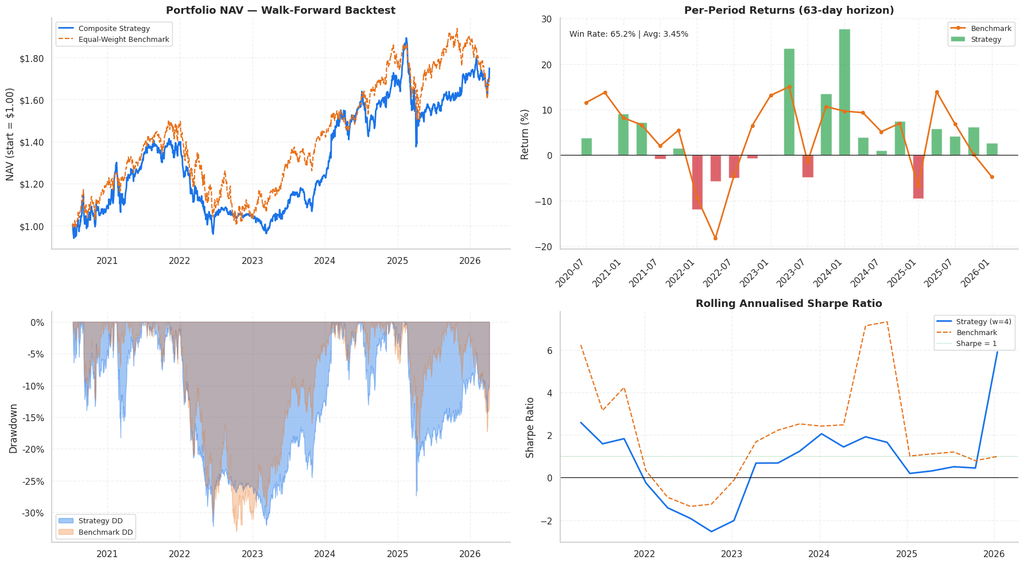

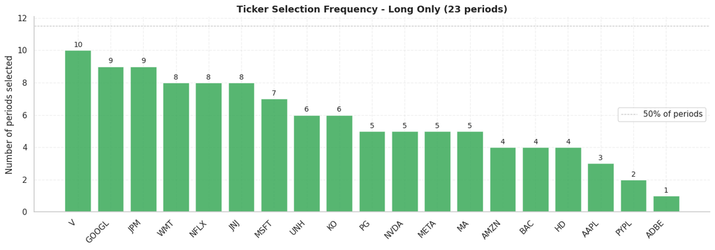

```python
import matplotlib.pyplot as plt
%matplotlib inline
# PLOTTING FUNCTIONS
# =============================================================================

C_STRAT = '#1a73e8'
C_BM = '#e8711a'
C_GRN = '#2da44e'
C_RED = '#cf222e'

plt.rcParams.update({
    'font.family': 'DejaVu Sans',
    'axes.spines.top': False,
    'axes.spines.right': False,
    'axes.grid': True,
    'grid.alpha': 0.3,
    'grid.linestyle': '--',
    'figure.dpi': 100
})

# =============================================================================
# FIGURE 1: NAV + Drawdown + Period Returns + Rolling Sharpe
# =============================================================================

fig = plt.figure(figsize=(18, 10))

# --- Top Left: NAV ---
ax1 = plt.subplot(2, 2, 1)
sn = port_df['strat_nav']
bn = port_df['bm_nav']

ax1.plot(sn.index, sn, color=C_STRAT, lw=2, label='Composite Strategy')
ax1.plot(bn.index, bn, color=C_BM, lw=1.5, ls='--', label='Equal-Weight Benchmark')
ax1.set_title('Portfolio NAV — Walk-Forward Backtest', fontsize=13, fontweight='bold')
ax1.set_ylabel('NAV (start = $1.00)')
ax1.legend(fontsize=9)
ax1.yaxis.set_major_formatter(FuncFormatter(lambda x, _: f'${x:.2f}'))

# --- Bottom Left: Drawdown ---
ax2 = plt.subplot(2, 2, 3)
dd_s = (sn / sn.cummax()) - 1
dd_b = (bn / bn.cummax()) - 1
ax2.fill_between(dd_s.index, dd_s, 0, color=C_STRAT, alpha=0.4, label='Strategy DD')
ax2.fill_between(dd_b.index, dd_b, 0, color=C_BM, alpha=0.3, label='Benchmark DD')
ax2.set_ylabel('Drawdown')
ax2.legend(fontsize=9)
ax2.yaxis.set_major_formatter(FuncFormatter(lambda x, _: f'{x:.0%}'))

# --- Top Right: Period Returns ---
ax3 = plt.subplot(2, 2, 2)
cols = [C_GRN if r > 0 else C_RED for r in trades_df['strat_ret']]
x_pos = np.arange(len(trades_df))

ax3.bar(x_pos, trades_df['strat_ret'] * 100, color=cols, alpha=0.7,
        label='Strategy', width=0.6)
ax3.plot(x_pos, trades_df['bm_ret'] * 100, color=C_BM, lw=2,
         marker='o', ms=4, label='Benchmark')
ax3.axhline(0, color='black', lw=0.8)

period_labels = [f"{d.strftime('%Y-%m')}" for d in trades_df['rebal_date']]
ax3.set_xticks(x_pos[::2])
ax3.set_xticklabels(period_labels[::2], rotation=45, ha='right')
ax3.set_ylabel('Return (%)')
ax3.set_title('Per-Period Returns (63-day horizon)', fontsize=13, fontweight='bold')
ax3.legend(fontsize=9)

win_rate = (trades_df['strat_ret'] > 0).mean()
avg_ret = trades_df['strat_ret'].mean()
ax3.text(0.02, 0.95, f'Win Rate: {win_rate:.1%} | Avg: {avg_ret:.2%}',
         transform=ax3.transAxes, fontsize=10, verticalalignment='top',
         bbox=dict(boxstyle='round', facecolor='white', alpha=0.8))

# --- Bottom Right: Rolling Sharpe ---
ax4 = plt.subplot(2, 2, 4)
rw = max(4, len(trades_df) // 5)
if len(trades_df) > rw:
    rs = trades_df.set_index('rebal_date')

    def roll_sh(col):
        roll_mean = rs[col].rolling(rw).mean()
        roll_std = rs[col].rolling(rw).std()
        return (roll_mean / (roll_std + 1e-10)) * np.sqrt(252 / HORIZON)

    sh_strat = roll_sh('strat_ret')
    sh_bm = roll_sh('bm_ret')

    ax4.plot(sh_strat.index, sh_strat, color=C_STRAT, lw=2,
             label=f'Strategy (w={rw})')
    ax4.plot(sh_bm.index, sh_bm, color=C_BM, lw=1.5, ls='--',
             label='Benchmark')

ax4.axhline(0, color='black', lw=0.8)
ax4.axhline(1, color=C_GRN, lw=0.8, ls=':', alpha=0.7, label='Sharpe = 1')
ax4.set_title('Rolling Annualised Sharpe Ratio', fontsize=13, fontweight='bold')
ax4.set_ylabel('Sharpe Ratio')
ax4.legend(fontsize=9)

plt.tight_layout()
plt.show()


# =============================================================================
# FIGURE 2: Ticker Selection Frequency
# =============================================================================

if 'long_tickers' in trades_df.columns:
    from collections import Counter

    long_counts = Counter(tk for row in trades_df['long_tickers'] for tk in row)
    all_tks = sorted(long_counts.keys(), key=lambda x: long_counts[x], reverse=True)

    if all_tks:
        fig, ax = plt.subplots(figsize=(14, 5))
        x = np.arange(len(all_tks))
        lv = [long_counts[t] for t in all_tks]

        bars = ax.bar(x, lv, color=C_GRN, alpha=0.8)

        for bar, val in zip(bars, lv):
            ax.text(bar.get_x() + bar.get_width()/2, bar.get_height() + 0.1,
                    str(val), ha='center', va='bottom', fontsize=10)

        ax.set_xticks(x)
        ax.set_xticklabels(all_tks, rotation=45, ha='right')
        ax.axhline(len(trades_df) / 2, color='gray', lw=0.8, ls='--',
                   alpha=0.5, label='50% of periods')
        ax.set_ylabel('Number of periods selected')
        ax.set_title(f'Ticker Selection Frequency - Long Only ({len(trades_df)} periods)',
                     fontsize=13, fontweight='bold')
        ax.legend()

        plt.tight_layout()
        plt.show()

plt.show()
```

## Limitations

- Fixed 63-Day Holding Period and Intra-Quarter Risk: The strategy operates on a strict 63-trading-day rebalancing schedule. While this effectively reduces turnover and transaction costs, it exposes the portfolio to intra-quarter drawdowns. Because the model holds its Top-5 allocations for the entire 63-day horizon, it cannot dynamically liquidate positions mid-cycle in response to sudden, idiosyncratic shocks (e.g., a disastrous earnings report or an unexpected executive departure).
- Survivorship Bias in the Data Universe: The model was tested on a fixed universe of 21 mega-cap US equities that successfully survived and thrived through 2026. Deploying this framework on a dynamic universe that includes delisted or severely depreciated companies might yield lower absolute returns, though the multi-factor risk-filtering mechanism is designed to naturally weed out failing assets.
- Exogenous Macroeconomic Shocks (Black Swans): The Monte Carlo simulations (GBM), Time Series algorithms, and Machine Learning models are trained on historical data distributions. They assume future volatility will probabilistically resemble the past. They cannot account for unpredictable “Black Swan” events - such as sudden geopolitical conflicts or global pandemics - that structurally break historical correlations within the 63-day forecast window.